# Simulating dynamic systems in R

Questions and answers for the models of the course

Dynamic Systems Thinking in Psychology

# How to use this guide

Every answer in this guide is **one complete script** that runs on its own. Copy it into a new R script, run it from top to bottom, and you get the data and a plot. Then change it to fit your own model.

- Each answer starts with a **blue box**: the short answer, usually the one or two lines you need to change.
- Lines that are new or changed compared with the basic script of Section 1.1 are marked with `# <-- NEW` or `# <-- CHANGE`.
- **Orange boxes** point out things that often go wrong.
- All scripts use **ggplot2** (`install.packages("ggplot2")` once). Nothing else is needed.
- Unless an answer says otherwise, **time is in days**, the construct is Albert’s mood, and the variable names are the ones from the course scripts: `times`, `Nsteps`, `Npeople`, `A`, `B`, `G`.

If you are new to the simulations, read Section 1.1 first. It explains every line of the basic script that all other answers build on.

The button **Code** at the top right downloads the R Markdown file with all scripts.

## I want to …

| I want to … | Go to | What to change |
| --- | --- | --- |
| add more participants | More participants | `Npeople <- 50` |
| measure more or less often, or for longer | Rating times | `times <- seq(0, 28, by = 0.25)` |
| switch the random kicks off | Kicks on and off | `G <- 0` |
| say where mood rests | Resting level | `B <- -A * restMood` |
| use weeks instead of days | Time unit | divide `A`, `B` by 7, `G` by `sqrt(7)` |
| add measurement error | Measurement error | `Rating <- Mood + rnorm(...)` |
| let people miss ratings | Missing ratings | set some rows to `NA` |
| let people differ in level, `A` or `G` | Individual differences | draw a value per person |
| let a trait predict the parameters | Trait as predictor | `A_i <- Atypical * exp(AeffectN * N_i)` |
| simulate a treatment and a control group | Two groups | a `group` column |
| simulate a straight line, AR(1) or VAR(1) | Discrete-time recipes | Section 4 |
| start therapy at week 5 | Switch a push on | `therapyOn` |
| let therapy change the baseline | Moving baseline | a second state |
| couple two constructs | Two constructs | `A12`, `A21` |
| add a third (or fourth) construct | A third construct | one more state and slope line |
| check if my system is stable | Stability | simulate without kicks |
| add a common cause (shared kicks) | Shared kicks | `Gs` |
| add a threshold or tipping point | Threshold | `moderator <- as.numeric(...)` |
| keep mood between 0 and 100 | Bounded process | latent scale + `plogis()` |
| add a one-off event | Transient shock | `shockTimes`, `dose` |
| add an event that starts its own process | Dissipative shock | `Ainput`, `C` |
| add repeated sessions | Cumulative shocks | `shockTimes <- seq(...)` |
| add random life events | Random events | `eventRate` |
| compare scenarios (“what if …”) | Scenarios | loop over values |
| save the data and the plots | Saving | `write.csv()`, `ggsave()` |
| check that my simulation is right | Checking | Section 9.4 |
| fix an error | Common problems | Section 9.5 |

# 1 The basic simulation

## 1.1 What does the basic simulation script look like?

The basic model of the course, $dMood = (A \cdot Mood + B)\,dt + G\,dW$, simulated with many small steps between two ratings. Every other answer in this guide is a variation of this script.

The rule says how mood **changes** at every moment. Between two ratings we take `Nsteps` small steps of size `dt`. In each small step we:

1. compute the slope from the **current** state: `dMood <- A*MoodState + B`,
2. move along that slope for a time `dt`: `dMood * dt`,
3. add a random kick with SD `G * sqrt(dt)` (the variance of the kicks grows with the length of time, so their SD grows with `sqrt(dt)`).

At each rating time we store the state that has been reached.

```r
library(ggplot2)

# --- Settings (time in days) ----------------------------------------------
times <- seq(from = 0, to = 14, by = 0.25)   # 4 ratings a day for 2 weeks
Nsteps <- 20                                 # small steps between two ratings

A <- -0.5          # state dependence: how strongly mood is pulled back (per day)
B <- 25            # continuous intercept: with A, sets the resting level -B/A = 50
G <- 3             # kick strength (process noise)
initialMood <- 30  # mood at the first rating

set.seed(2026)     # same random kicks every time you run this

# --- The simulation function ----------------------------------------------
simulateMood <- function(A, B, G, initialMood, times, Nsteps){
  Nobs <- length(times)                        # number of ratings
  Mood <- rep(NA, Nobs)                        # empty vector for the ratings
  MoodState <- initialMood                     # the state we update
  for(i in 1:Nobs){
    if(i > 1){
      dt <- (times[i] - times[i-1]) / Nsteps   # size of each small step
      for(stepi in 1:Nsteps){
        dMood <- A*MoodState + B               # the rule: slope at the current state
        kick <- G * sqrt(dt) * rnorm(1)        # random kick, variance G^2 * dt
        MoodState <- MoodState + dMood * dt + kick
      }
    }
    Mood[i] <- MoodState                       # store the state at this rating
  }
  data.frame(time = times, Mood = Mood)
}

# --- Run it -------------------------------------------------------------------
albert <- simulateMood(A = A, B = B, G = G, initialMood = initialMood,
                       times = times, Nsteps = Nsteps)
head(albert)
```

```
##   time     Mood
## 1 0.00 30.00000
## 2 0.25 29.91425
## 3 0.50 34.22602
## 4 0.75 34.47288
## 5 1.00 36.30961
## 6 1.25 36.96536
```

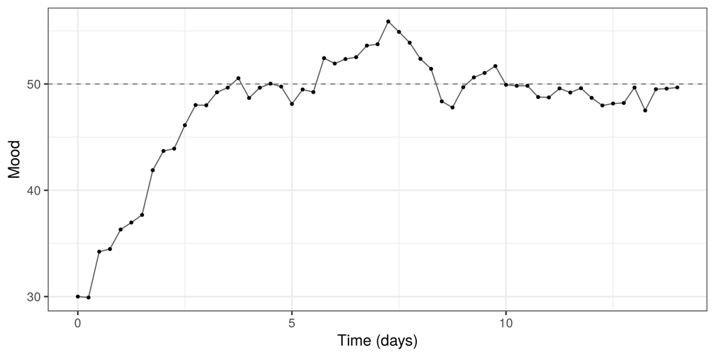

| Name | Meaning |
| --- | --- |
| `times` | the moments at which mood is rated (here in days) |
| `Nsteps` | number of small steps between two ratings |
| `A` | state dependence (per day). Negative: mood is pulled back to its resting level. Closer to 0: slower return |
| `B` | continuous intercept. Together with `A` it sets the resting level, `-B/A` |
| `G` | kick strength (process noise) |
| `MoodState` | the current mood *between* ratings; `Mood[i]` is what we store at rating `i` |

```r
# --- Plot it ------------------------------------------------------------------
ggplot(albert, aes(x = time, y = Mood)) +
  geom_hline(yintercept = -B/A, linetype = "dashed", colour = "grey50") +  # resting level
  geom_line(colour = "grey40") +
  geom_point(size = 1) +
  theme_bw(base_size = 14) +
  labs(x = "Time (days)", y = "Mood")
```

The course scripts kept `times` and `Nsteps` outside the function. Here they are **arguments** of the function, so that you can see everything the function uses in its first line. Both versions give the same result.

## 1.2 How do I turn the random kicks off, or make them stronger?

`G <- 0` switches the kicks off; a larger `G` makes them stronger. Running the model once with and once without kicks shows what the rule does on its own.

How far mood typically wanders from its resting level in the long run is `G / sqrt(2 * -A)`. So the same `G` gives larger fluctuations when `A` is closer to 0.

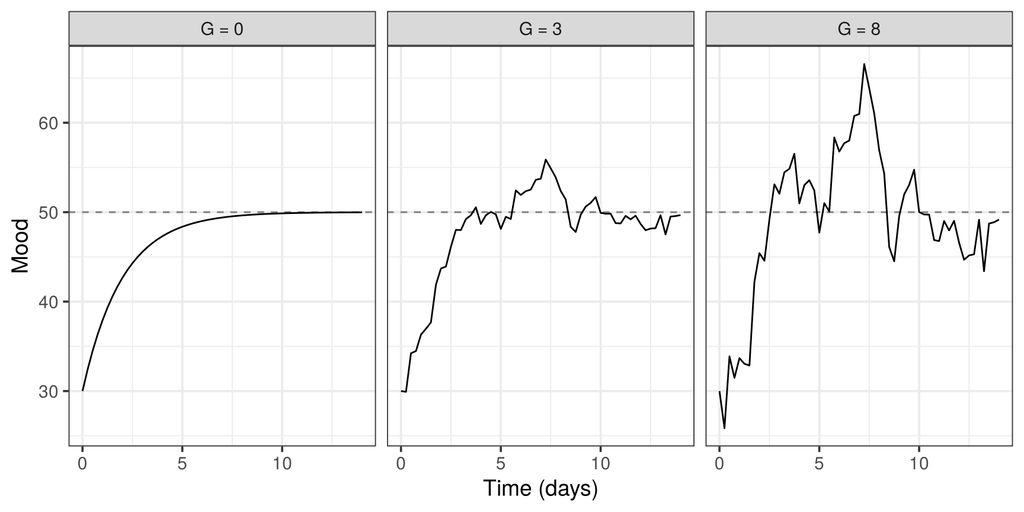

```r
library(ggplot2)

times <- seq(from = 0, to = 14, by = 0.25)
Nsteps <- 20
A <- -0.5
B <- 25
initialMood <- 30

simulateMood <- function(A, B, G, initialMood, times, Nsteps){
  Nobs <- length(times)
  Mood <- rep(NA, Nobs)
  MoodState <- initialMood
  for(i in 1:Nobs){
    if(i > 1){
      dt <- (times[i] - times[i-1]) / Nsteps
      for(stepi in 1:Nsteps){
        dMood <- A*MoodState + B
        kick <- G * sqrt(dt) * rnorm(1)
        MoodState <- MoodState + dMood * dt + kick
      }
    }
    Mood[i] <- MoodState
  }
  data.frame(time = times, Mood = Mood)
}

dat <- NULL
for (Gvalue in c(0, 3, 8)) {   # <-- NEW: three kick strengths
  set.seed(2026)   # same random numbers for each
  sim <- simulateMood(A = A, B = B, G = Gvalue, initialMood = initialMood,
                      times = times, Nsteps = Nsteps)
  sim$G <- paste("G =", Gvalue)
  dat <- rbind(dat, sim)
}

ggplot(dat, aes(x = time, y = Mood)) +
  geom_hline(yintercept = -B/A, linetype = "dashed", colour = "grey50") +
  geom_line() +
  facet_wrap(~ G) +
  theme_bw(base_size = 14) +
  labs(x = "Time (days)", y = "Mood")
```

```r
c(G3 = 3 / sqrt(2 * -A), G8 = 8 / sqrt(2 * -A))   # long-run SD around the resting level
```

```
## G3 G8
##  3  8
```

## 1.3 How do I set where mood rests, instead of choosing B?

Choose the resting level and compute `B` from it: `B <- -A * restMood`. Then you can change `A` without the resting level moving.

The resting level (equilibrium) is where the slope is 0: $A \cdot Mood + B = 0$, so $Mood^* = -B/A$. If you change `A` but keep `B`, the resting level moves too. Computing `B` from the level you want avoids that.

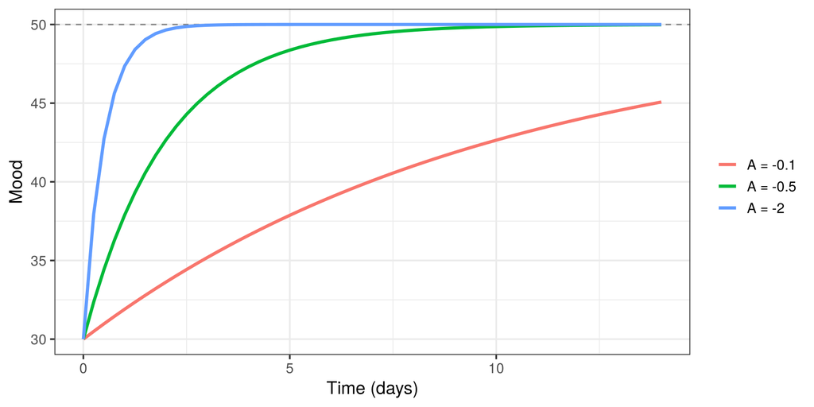

```r
library(ggplot2)

times <- seq(from = 0, to = 14, by = 0.25)
Nsteps <- 20
G <- 0                      # no kicks, so you can see the rule
restMood <- 50              # <-- NEW: where mood rests
initialMood <- 30

simulateMood <- function(A, B, G, initialMood, times, Nsteps){
  Nobs <- length(times)
  Mood <- rep(NA, Nobs)
  MoodState <- initialMood
  for(i in 1:Nobs){
    if(i > 1){
      dt <- (times[i] - times[i-1]) / Nsteps
      for(stepi in 1:Nsteps){
        dMood <- A*MoodState + B
        kick <- G * sqrt(dt) * rnorm(1)
        MoodState <- MoodState + dMood * dt + kick
      }
    }
    Mood[i] <- MoodState
  }
  data.frame(time = times, Mood = Mood)
}

dat <- NULL
for (A in c(-2, -0.5, -0.1)) {
  B <- -A * restMood   # <-- NEW: B that puts the rest at restMood
  sim <- simulateMood(A = A, B = B, G = G, initialMood = initialMood,
                      times = times, Nsteps = Nsteps)
  sim$A <- paste("A =", A)
  dat <- rbind(dat, sim)
}

ggplot(dat, aes(x = time, y = Mood, colour = A)) +
  geom_hline(yintercept = restMood, linetype = "dashed", colour = "grey50") +
  geom_line(linewidth = 1.2) +
  theme_bw(base_size = 14) +
  labs(x = "Time (days)", y = "Mood", colour = NULL)
```

All three return to 50; `A` only sets how fast. A useful number: half of a deviation is gone after `log(2) / -A` days (the half-life).

## 1.4 How do I start someone away from their resting level?

Change `initialMood`. To start everyone at their resting level, use `initialMood <- restMood`.

A start far from the resting level shows the rule (the return), a start at the resting level shows the kicks only. Which one you want depends on your story: does the study start right after something happened, or on an ordinary day?

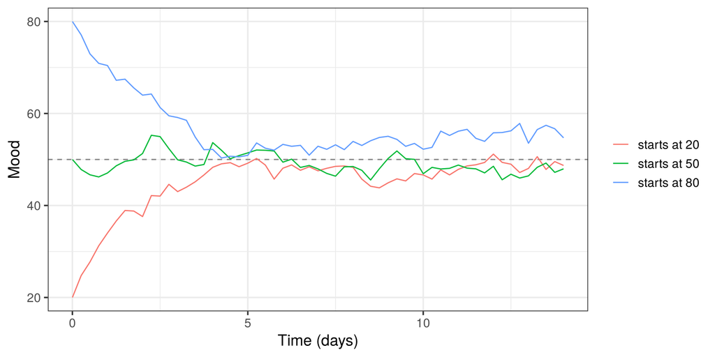

```r
library(ggplot2)

times <- seq(from = 0, to = 14, by = 0.25)
Nsteps <- 20
A <- -0.5
restMood <- 50
B <- -A * restMood
G <- 3

simulateMood <- function(A, B, G, initialMood, times, Nsteps){
  Nobs <- length(times)
  Mood <- rep(NA, Nobs)
  MoodState <- initialMood
  for(i in 1:Nobs){
    if(i > 1){
      dt <- (times[i] - times[i-1]) / Nsteps
      for(stepi in 1:Nsteps){
        dMood <- A*MoodState + B
        kick <- G * sqrt(dt) * rnorm(1)
        MoodState <- MoodState + dMood * dt + kick
      }
    }
    Mood[i] <- MoodState
  }
  data.frame(time = times, Mood = Mood)
}

set.seed(1)
dat <- NULL
for (start in c(20, 50, 80)) {   # <-- NEW: three starting values
  sim <- simulateMood(A = A, B = B, G = G, initialMood = start,
                      times = times, Nsteps = Nsteps)
  sim$start <- paste("starts at", start)
  dat <- rbind(dat, sim)
}

ggplot(dat, aes(x = time, y = Mood, colour = start)) +
  geom_hline(yintercept = restMood, linetype = "dashed", colour = "grey50") +
  geom_line() +
  theme_bw(base_size = 14) +
  labs(x = "Time (days)", y = "Mood", colour = NULL)
```

If the start is far from the resting level, the first days of data are mostly “return to rest”. If your story is about ordinary fluctuations, start at the resting level, or drop the first days (a *burn-in*).

## 1.5 How do I get the same random numbers every time?

Put `set.seed(2026)` (any number) **before** the simulation. To compare two versions of a model with the same kicks, call `set.seed()` again right before each version.

```r
library(ggplot2)

times <- seq(from = 0, to = 14, by = 0.25)
Nsteps <- 20
A <- -0.5
B <- 25
G <- 3

simulateMood <- function(A, B, G, initialMood, times, Nsteps){
  Nobs <- length(times)
  Mood <- rep(NA, Nobs)
  MoodState <- initialMood
  for(i in 1:Nobs){
    if(i > 1){
      dt <- (times[i] - times[i-1]) / Nsteps
      for(stepi in 1:Nsteps){
        dMood <- A*MoodState + B
        kick <- G * sqrt(dt) * rnorm(1)
        MoodState <- MoodState + dMood * dt + kick
      }
    }
    Mood[i] <- MoodState
  }
  data.frame(time = times, Mood = Mood)
}

set.seed(2026)                                                           # <-- NEW
run1 <- simulateMood(A, B, G, initialMood = 50, times = times, Nsteps = Nsteps)
set.seed(2026)   # <-- NEW: same seed again
run2 <- simulateMood(A, B, G, initialMood = 50, times = times, Nsteps = Nsteps)
run3 <- simulateMood(A, B, G, initialMood = 50, times = times, Nsteps = Nsteps)  # no new seed

identical(run1$Mood, run2$Mood)   # TRUE: same kicks
```

```
## [1] TRUE
```

```r
identical(run1$Mood, run3$Mood)   # FALSE: new kicks
```

```
## [1] FALSE
```

The kicks are drawn in order. If you change the number of draws (more people, more steps, an extra `rnorm()` for measurement error), the later kicks change too, even with the same seed. For a clean comparison of two models, give each model its own `set.seed()` right before it.

## 1.6 How many small steps (Nsteps) do I need?

Enough that `abs(A) * dt` is small (below about 0.05), where `dt = (time between ratings) / Nsteps`. Check: double `Nsteps`. If the result hardly changes, you have enough.

With too few steps, the slope is held fixed for too long, and the simulation overshoots (Euler’s method). With `Nsteps <- 1`, the model becomes an AR(1) with $\phi = 1 + A\,\Delta t$ instead of the correct $e^{A\Delta t}$. Coupled and nonlinear models (thresholds, oscillations) need more steps than a single linear construct.

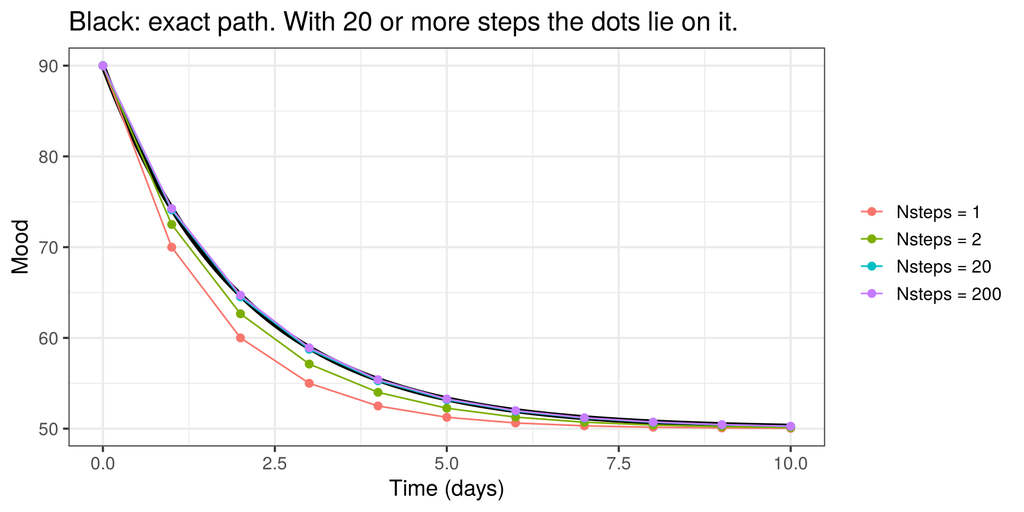

```r
library(ggplot2)

times <- seq(from = 0, to = 10, by = 1)      # one rating a day
A <- -0.5
B <- 25
G <- 0                                       # no kicks: we only look at the rule

simulateMood <- function(A, B, G, initialMood, times, Nsteps){
  Nobs <- length(times)
  Mood <- rep(NA, Nobs)
  MoodState <- initialMood
  for(i in 1:Nobs){
    if(i > 1){
      dt <- (times[i] - times[i-1]) / Nsteps
      for(stepi in 1:Nsteps){
        dMood <- A*MoodState + B
        kick <- G * sqrt(dt) * rnorm(1)
        MoodState <- MoodState + dMood * dt + kick
      }
    }
    Mood[i] <- MoodState
  }
  data.frame(time = times, Mood = Mood)
}

dat <- NULL
for (n in c(1, 2, 20, 200)) {   # <-- NEW: different Nsteps
  sim <- simulateMood(A, B, G, initialMood = 90, times = times, Nsteps = n)
  sim$Nsteps <- paste("Nsteps =", n)
  dat <- rbind(dat, sim)
}
dat$Nsteps <- factor(dat$Nsteps, levels = paste("Nsteps =", c(1, 2, 20, 200)))

exact <- data.frame(time = seq(0, 10, 0.05))
exact$Mood <- 50 + (90 - 50) * exp(A * exact$time)               # the exact solution

ggplot(dat, aes(x = time, y = Mood, colour = Nsteps)) +
  geom_line(data = exact, colour = "black", linewidth = 1.5) +
  geom_line() + geom_point(size = 2) +
  theme_bw(base_size = 14) +
  labs(x = "Time (days)", y = "Mood", colour = NULL,
       title = "Black: exact path. With 20 or more steps the dots lie on it.")
```

# 2 Time and measurement

## 2.1 How do I change how often people rate, and how long the study lasts?

Change `times`. `by` is the time between two ratings, `to` is the length of the study. For example `times <- seq(from = 0, to = 28, by = 1)` is one rating a day for four weeks.

The model’s parameters do not change when you change `times`: the process is the same, you only look at it more or less often. `Nsteps` is the number of small steps *between two ratings*, so with fewer ratings you may need a larger `Nsteps` (see Nsteps).

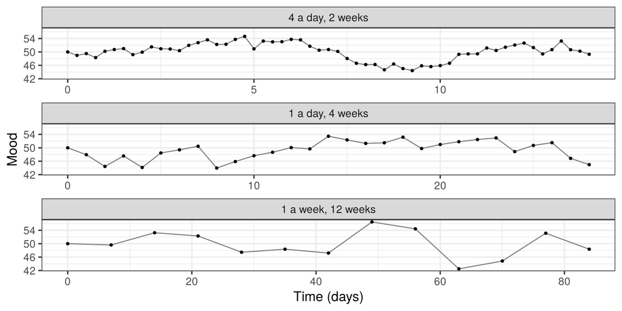

```r
library(ggplot2)

A <- -0.5
B <- 25
G <- 3

simulateMood <- function(A, B, G, initialMood, times, Nsteps){
  Nobs <- length(times)
  Mood <- rep(NA, Nobs)
  MoodState <- initialMood
  for(i in 1:Nobs){
    if(i > 1){
      dt <- (times[i] - times[i-1]) / Nsteps
      for(stepi in 1:Nsteps){
        dMood <- A*MoodState + B
        kick <- G * sqrt(dt) * rnorm(1)
        MoodState <- MoodState + dMood * dt + kick
      }
    }
    Mood[i] <- MoodState
  }
  data.frame(time = times, Mood = Mood)
}

designs <- list("4 a day, 2 weeks"   = seq(from = 0, to = 14, by = 0.25),   # <-- CHANGE these
                "1 a day, 4 weeks"   = seq(from = 0, to = 28, by = 1),
                "1 a week, 12 weeks" = seq(from = 0, to = 84, by = 7))

set.seed(3)
dat <- NULL
for (d in names(designs)) {
  times <- designs[[d]]
  Nsteps <- max(20, ceiling(20 * (times[2] - times[1])))   # keep the small steps small
  sim <- simulateMood(A, B, G, initialMood = 50, times = times, Nsteps = Nsteps)
  sim$design <- d
  dat <- rbind(dat, sim)
}
dat$design <- factor(dat$design, levels = names(designs))

ggplot(dat, aes(x = time, y = Mood)) +
  geom_line(colour = "grey50") + geom_point(size = 1) +
  facet_wrap(~ design, ncol = 1, scales = "free_x") +
  theme_bw(base_size = 14) +
  labs(x = "Time (days)", y = "Mood")
```

With weekly ratings and `A = -0.5` (half-life 1.4 days), every rating looks unrelated to the one before: the process has forgotten everything within a week. The model did not change, only the design.

## 2.2 How do I change the time unit, for example from weeks to days?

From per-week to per-day: divide `A` and `B` by 7, and `G` by `sqrt(7)`. Then express `times` in days. In general, for a factor `k` (7 for weeks to days): `A/k`, `B/k`, `G/sqrt(k)`.

`A` and `B` are rates (per unit of time), so they scale with the unit. `G` scales with the square root, because the *variance* of the kicks grows in proportion to time. The resting level `-B/A` and the long-run SD `G/sqrt(2|A|)` stay the same.

```r
library(ggplot2)

simulateMood <- function(A, B, G, initialMood, times, Nsteps){
  Nobs <- length(times)
  Mood <- rep(NA, Nobs)
  MoodState <- initialMood
  for(i in 1:Nobs){
    if(i > 1){
      dt <- (times[i] - times[i-1]) / Nsteps
      for(stepi in 1:Nsteps){
        dMood <- A*MoodState + B
        kick <- G * sqrt(dt) * rnorm(1)
        MoodState <- MoodState + dMood * dt + kick
      }
    }
    Mood[i] <- MoodState
  }
  data.frame(time = times, Mood = Mood)
}

# values per WEEK
Aweek <- -0.2; Bweek <- 2; Gweek <- 1.5
timesWeeks <- seq(from = 0, to = 20, by = 1/7)        # daily ratings, in weeks

# the same process, per DAY
Aday <- Aweek / 7                                     # <-- CHANGE: rates divide by 7
Bday <- Bweek / 7
Gday <- Gweek / sqrt(7)   # <-- CHANGE: kick strength divides by sqrt(7)
timesDays <- timesWeeks * 7                           # the same ratings, in days

set.seed(4)
inWeeks <- simulateMood(Aweek, Bweek, Gweek, initialMood = 3, times = timesWeeks, Nsteps = 20)
set.seed(4)
inDays  <- simulateMood(Aday, Bday, Gday, initialMood = 3, times = timesDays, Nsteps = 20)

max(abs(inWeeks$Mood - inDays$Mood))    # practically 0: the same simulation
```

```
## [1] 2.4869e-14
```

```r
c(restWeeks = -Bweek/Aweek, restDays = -Bday/Aday)
```

```
## restWeeks  restDays
##        10        10
```

```r
c(sdWeeks = Gweek/sqrt(2*-Aweek), sdDays = Gday/sqrt(2*-Aday))
```

```
##  sdWeeks   sdDays
## 2.371708 2.371708
```

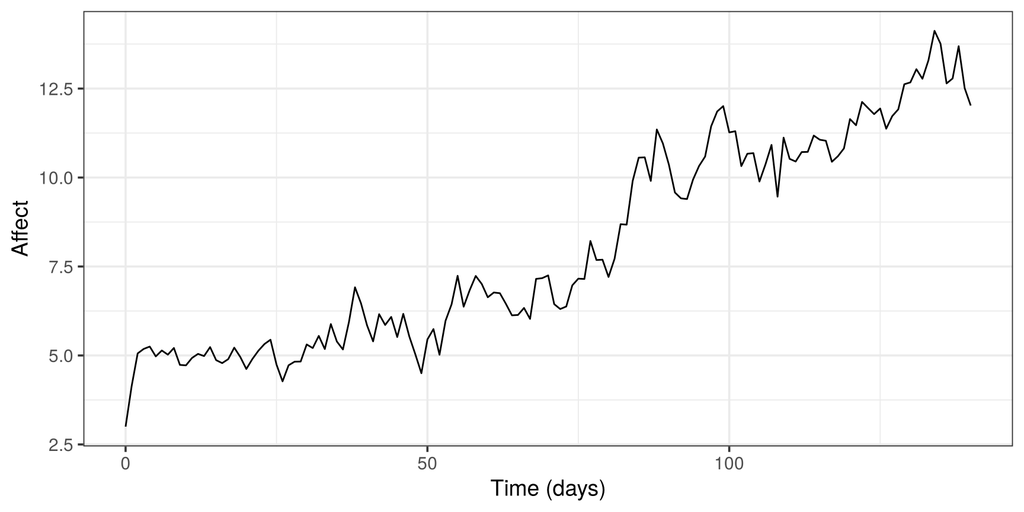

```r
ggplot(inDays, aes(x = time, y = Mood)) +
  geom_line() +
  theme_bw(base_size = 14) +
  labs(x = "Time (days)", y = "Affect")
```

## 2.3 How do I make ratings at irregular times?

Give `times` any increasing set of values, for example `times <- sort(c(0, runif(55, 0, 14)))`. The function already uses the real gap between two ratings to compute `dt`.

Because `dt` is computed per interval, a long gap gets long small steps. To keep every small step short, the version below sets the number of small steps per interval from a maximum step size, `maxdt`.

```r
library(ggplot2)

A <- -0.5
B <- 25
G <- 3
maxdt <- 0.01                     # <-- NEW: longest small step (days)

simulateMood <- function(A, B, G, initialMood, times, maxdt){
  Nobs <- length(times)
  Mood <- rep(NA, Nobs)
  MoodState <- initialMood
  for(i in 1:Nobs){
    if(i > 1){
      gap <- times[i] - times[i-1]
      Nsteps <- ceiling(gap / maxdt)   # <-- CHANGE: more steps for longer gaps
      dt <- gap / Nsteps
      for(stepi in 1:Nsteps){
        dMood <- A*MoodState + B
        kick <- G * sqrt(dt) * rnorm(1)
        MoodState <- MoodState + dMood * dt + kick
      }
    }
    Mood[i] <- MoodState
  }
  data.frame(time = times, Mood = Mood)
}

set.seed(5)
times <- sort(c(0, runif(55, min = 0, max = 14)))   # <-- CHANGE: 56 ratings at random times

# A more realistic diary: 5 prompts a day at random times between 8:00 and 22:00
# times <- sort(as.vector(sapply(0:13, function(day) day + runif(5, 8/24, 22/24))))

albert <- simulateMood(A, B, G, initialMood = 50, times = times, maxdt = maxdt)
summary(diff(albert$time))           # the gaps between ratings
```

```
##    Min. 1st Qu.  Median    Mean 3rd Qu.    Max.
## 0.01190 0.07923 0.14969 0.24841 0.39965 0.92642
```

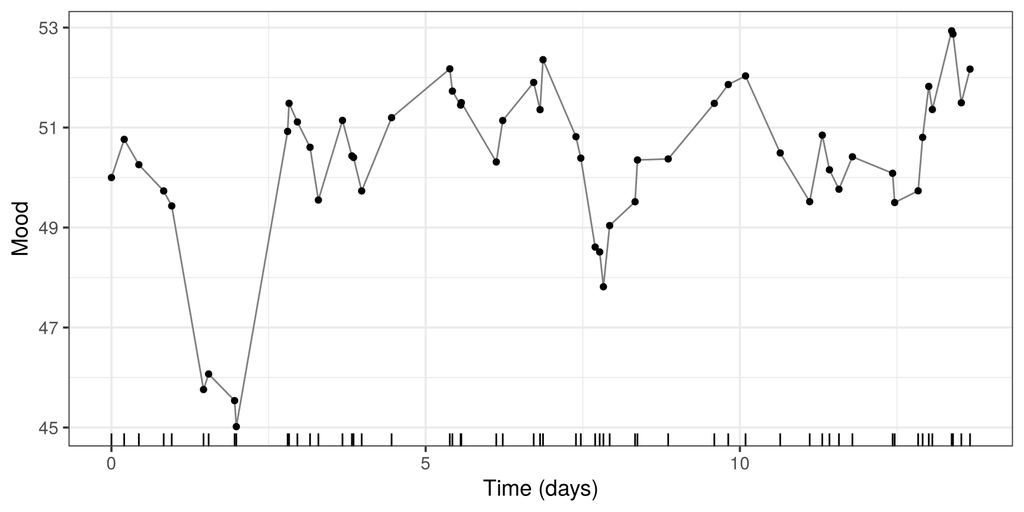

```r
ggplot(albert, aes(x = time, y = Mood)) +
  geom_line(colour = "grey50") + geom_point() +
  geom_rug(sides = "b") +
  theme_bw(base_size = 14) +
  labs(x = "Time (days)", y = "Mood")
```

## 2.4 How do I make people miss some ratings?

Simulate all ratings, then set some to `NA`: `dat$Mood[runif(nrow(dat)) < 0.2] <- NA` (20% missing at random). Do this **after** the simulation, so the process itself keeps running.

Missing ratings are a property of the measurement, not of the process: mood goes on when Albert skips a prompt. The second version makes missing ratings depend on mood (people skip more on bad days), which is more realistic and more harmful for estimates.

```r
library(ggplot2)

times <- seq(from = 0, to = 28, by = 0.25)
Nsteps <- 20
A <- -0.5
B <- 25
G <- 6

simulateMood <- function(A, B, G, initialMood, times, Nsteps){
  Nobs <- length(times)
  Mood <- rep(NA, Nobs)
  MoodState <- initialMood
  for(i in 1:Nobs){
    if(i > 1){
      dt <- (times[i] - times[i-1]) / Nsteps
      for(stepi in 1:Nsteps){
        dMood <- A*MoodState + B
        kick <- G * sqrt(dt) * rnorm(1)
        MoodState <- MoodState + dMood * dt + kick
      }
    }
    Mood[i] <- MoodState
  }
  data.frame(time = times, Mood = Mood)
}

set.seed(6)
albert <- simulateMood(A, B, G, initialMood = 50, times = times, Nsteps = Nsteps)

# (a) missing completely at random: every rating has a 20% chance to be missed
albert$MoodRandom <- albert$Mood
albert$MoodRandom[runif(nrow(albert)) < 0.2] <- NA                  # <-- NEW

# (b) missing more often on bad days: chance of missing goes up as mood goes down
pMiss <- plogis(-1.5 - 0.3 * (albert$Mood - 50))                    # <-- NEW
albert$MoodLowMissing <- albert$Mood
albert$MoodLowMissing[runif(nrow(albert)) < pMiss] <- NA

colMeans(is.na(albert[, c("MoodRandom", "MoodLowMissing")]))        # share missing
```

```
##     MoodRandom MoodLowMissing
##      0.1946903      0.2389381
```

```r
c(true = mean(albert$Mood),
  random = mean(albert$MoodRandom, na.rm = TRUE),
  lowMissing = mean(albert$MoodLowMissing, na.rm = TRUE))   # (b) looks too happy
```

```
##       true     random lowMissing
##   49.14323   49.21043   50.19853
```

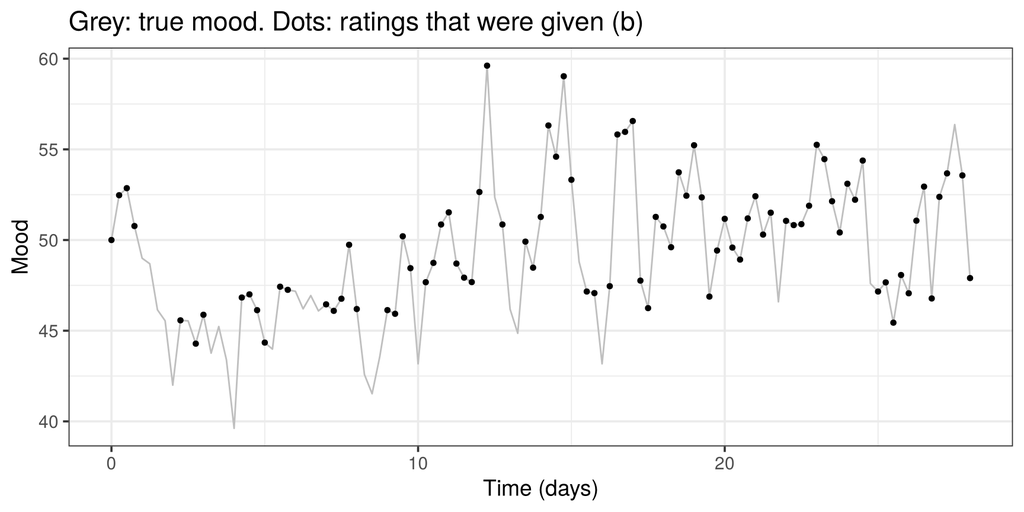

```r
ggplot(albert, aes(x = time)) +
  geom_line(aes(y = Mood), colour = "grey75") +
  geom_point(aes(y = MoodLowMissing), size = 1.2) +
  theme_bw(base_size = 14) +
  labs(x = "Time (days)", y = "Mood",
       title = "Grey: true mood. Dots: ratings that were given (b)")
```

To drop the missing rows instead of keeping `NA`s, use `albert[!is.na(albert$MoodRandom), ]`. Many fitting functions want one of the two; keep the full data frame as well, so you can compare.

## 2.5 How do I add measurement error?

After the simulation, add independent noise to every rating: `dat$Rating <- dat$Mood + rnorm(nrow(dat), mean = 0, sd = errorSD)`. Keep the true `Mood` as a separate column.

Process noise (`G`) kicks mood itself, and the kicks carry over. Measurement error only affects the **number Albert writes down**: the next rating does not remember it. That is why it is added outside the simulation loop.

```r
library(ggplot2)

times <- seq(from = 0, to = 14, by = 0.25)
Nsteps <- 20
A <- -0.5
B <- 25
G <- 3
errorSD <- 4                      # <-- NEW: SD of the measurement error

simulateMood <- function(A, B, G, initialMood, times, Nsteps){
  Nobs <- length(times)
  Mood <- rep(NA, Nobs)
  MoodState <- initialMood
  for(i in 1:Nobs){
    if(i > 1){
      dt <- (times[i] - times[i-1]) / Nsteps
      for(stepi in 1:Nsteps){
        dMood <- A*MoodState + B
        kick <- G * sqrt(dt) * rnorm(1)
        MoodState <- MoodState + dMood * dt + kick
      }
    }
    Mood[i] <- MoodState
  }
  data.frame(time = times, Mood = Mood)
}

set.seed(7)
albert <- simulateMood(A, B, G, initialMood = 50, times = times, Nsteps = Nsteps)
albert$Rating <- albert$Mood + rnorm(nrow(albert), mean = 0, sd = errorSD)   # <-- NEW

# reliability: true variance / (true variance + error variance)
var(albert$Mood) / var(albert$Rating)
```

```
## [1] 0.3457599
```

```r
# measurement error makes ratings look less sticky
c(lag1true = cor(albert$Mood[-1], albert$Mood[-nrow(albert)]),
  lag1rated = cor(albert$Rating[-1], albert$Rating[-nrow(albert)]))
```

```
##  lag1true lag1rated
## 0.8520761 0.2995023
```

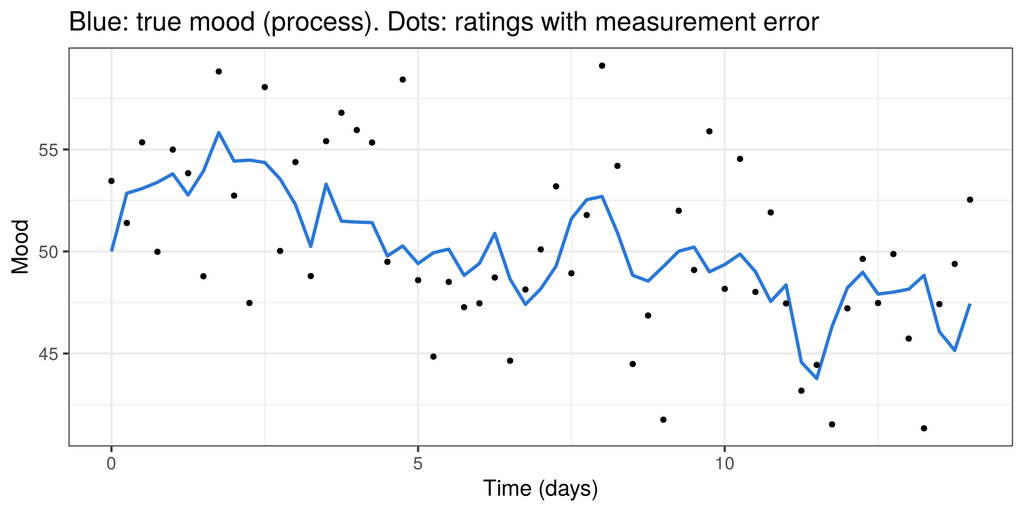

```r
ggplot(albert, aes(x = time)) +
  geom_line(aes(y = Mood), colour = "#2a78d6", linewidth = 1) +
  geom_point(aes(y = Rating), size = 1.2) +
  theme_bw(base_size = 14) +
  labs(x = "Time (days)", y = "Mood",
       title = "Blue: true mood (process). Dots: ratings with measurement error")
```

## 2.6 How do I round ratings and keep them on the 0-100 scale?

After the simulation: `dat$Rating <- pmin(pmax(round(dat$Mood), 0), 100)`. `round()` gives whole numbers, `pmax(..., 0)` sets everything below 0 to 0, `pmin(..., 100)` sets everything above 100 to 100.

This changes only the **ratings**, like a slider that cannot go further. The process underneath can still go below 0. If many ratings pile up at 0 or 100, your parameters put the process too close to the edge: move the resting level, lower `G`, or make the process itself bounded (see Bounded process).

```r
library(ggplot2)

times <- seq(from = 0, to = 28, by = 0.25)
Nsteps <- 20
A <- -0.3
B <- -A * 85                      # resting level 85: close to the top of the scale
G <- 10

simulateMood <- function(A, B, G, initialMood, times, Nsteps){
  Nobs <- length(times)
  Mood <- rep(NA, Nobs)
  MoodState <- initialMood
  for(i in 1:Nobs){
    if(i > 1){
      dt <- (times[i] - times[i-1]) / Nsteps
      for(stepi in 1:Nsteps){
        dMood <- A*MoodState + B
        kick <- G * sqrt(dt) * rnorm(1)
        MoodState <- MoodState + dMood * dt + kick
      }
    }
    Mood[i] <- MoodState
  }
  data.frame(time = times, Mood = Mood)
}

set.seed(8)
albert <- simulateMood(A, B, G, initialMood = 85, times = times, Nsteps = Nsteps)
albert$Rating <- pmin(pmax(round(albert$Mood), 0), 100)   # <-- NEW

mean(albert$Rating == 100)        # share of ratings stuck at the top
```

```
## [1] 0.1061947
```

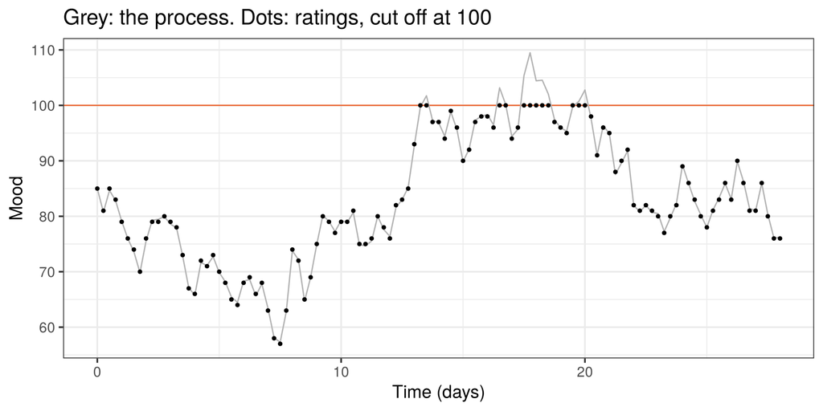

```r
ggplot(albert, aes(x = time)) +
  geom_hline(yintercept = 100, colour = "#eb6834") +
  geom_line(aes(y = Mood), colour = "grey70") +
  geom_point(aes(y = Rating), size = 1) +
  theme_bw(base_size = 14) +
  labs(x = "Time (days)", y = "Mood",
       title = "Grey: the process. Dots: ratings, cut off at 100")
```

## 2.7 How do I show the true path between ratings, and the ratings on top?

Put the rating times **into** a fine time grid, `allTimes <- sort(unique(round(c(fineTimes, ratingTimes), 8)))`, simulate at `allTimes`, and then keep the rows at the rating times: `ratings <- fine[fine$time %in% round(ratingTimes, 8), ]`.

The simulation already moves through the time between ratings, but it only stores the state at the rating times. Storing more often lets you plot what happens in between, which is useful to show what a study design misses.

The rating times must be **in** the fine grid, otherwise there is nothing to keep. A grid with `by = 0.02` has 0.74 and 0.76, but not 0.75 (18:00), so `%in%` would find no ratings at all, without any error message. Adding the rating times to the grid avoids that for any rating times. Use `round(..., 8)` when comparing times, because `seq()` can produce values like `0.30000000000000004`, and check with `nrow(ratings)`.

```r
library(ggplot2)

A <- -0.5
B <- 25
G <- 6

simulateMood <- function(A, B, G, initialMood, times, Nsteps){
  Nobs <- length(times)
  Mood <- rep(NA, Nobs)
  MoodState <- initialMood
  for(i in 1:Nobs){
    if(i > 1){
      dt <- (times[i] - times[i-1]) / Nsteps
      for(stepi in 1:Nsteps){
        dMood <- A*MoodState + B
        kick <- G * sqrt(dt) * rnorm(1)
        MoodState <- MoodState + dMood * dt + kick
      }
    }
    Mood[i] <- MoodState
  }
  data.frame(time = times, Mood = Mood)
}

fineTimes <- seq(from = 0, to = 14, by = 0.02)   # <-- NEW: store the state about every half hour
ratingTimes <- seq(from = 0.75, to = 13.75, by = 1)   # <-- NEW: one rating every evening (18:00)
allTimes <- sort(unique(round(c(fineTimes, ratingTimes), 8)))   # <-- NEW: rating times inside the grid

set.seed(9)
fine <- simulateMood(A, B, G, initialMood = 50, times = allTimes, Nsteps = 2)
ratings <- fine[fine$time %in% round(ratingTimes, 8), ]   # <-- NEW: keep only the rating times
nrow(ratings)                                         # 14 ratings: one every evening
```

```
## [1] 14
```

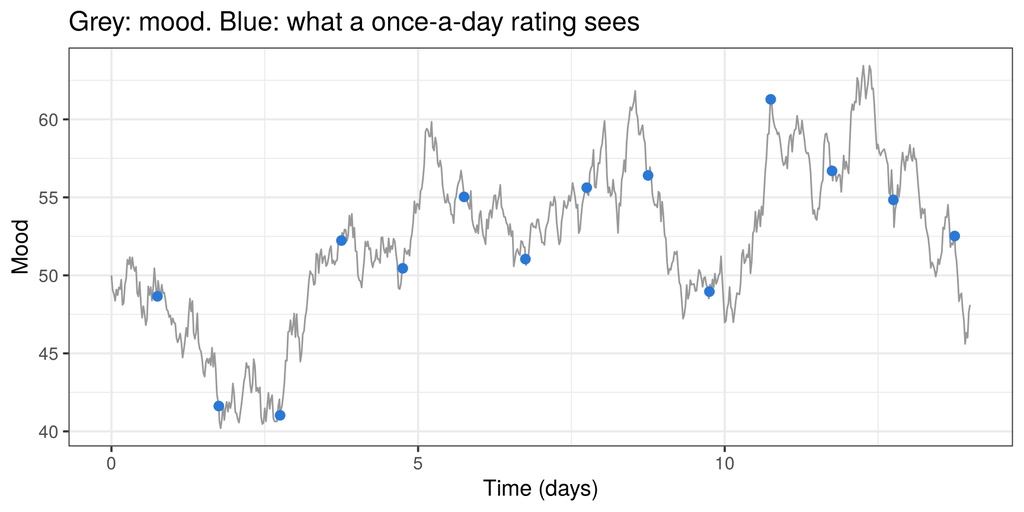

```r
ggplot(fine, aes(x = time, y = Mood)) +
  geom_line(colour = "grey60") +
  geom_point(data = ratings, colour = "#2a78d6", size = 2.5) +
  theme_bw(base_size = 14) +
  labs(x = "Time (days)", y = "Mood",
       title = "Grey: mood. Blue: what a once-a-day rating sees")
```

# 3 More people and individual differences

## 3.1 How do I add more participants?

Set `Npeople <- 50` and simulate each person in a loop. Stack the people below each other in one data frame with an `id` column (long format).

In this answer all people have the same parameters, so they differ only in their random kicks. The next answers let them differ in their parameters.

```r
library(ggplot2)

Npeople <- 50                              # <-- NEW: number of participants
times <- seq(from = 0, to = 14, by = 0.25)
Nsteps <- 20
A <- -0.5
B <- 25
G <- 3

simulateMood <- function(A, B, G, initialMood, times, Nsteps){
  Nobs <- length(times)
  Mood <- rep(NA, Nobs)
  MoodState <- initialMood
  for(i in 1:Nobs){
    if(i > 1){
      dt <- (times[i] - times[i-1]) / Nsteps
      for(stepi in 1:Nsteps){
        dMood <- A*MoodState + B
        kick <- G * sqrt(dt) * rnorm(1)
        MoodState <- MoodState + dMood * dt + kick
      }
    }
    Mood[i] <- MoodState
  }
  data.frame(time = times, Mood = Mood)
}

set.seed(10)
dat <- NULL
for (person in 1:Npeople) {   # <-- NEW: one loop over people
  sim <- simulateMood(A, B, G, initialMood = 50, times = times, Nsteps = Nsteps)
  dat <- rbind(dat, data.frame(id = person, sim))   # add this person's rows
}
head(dat)
```

```
##   id time     Mood
## 1  1 0.00 50.00000
## 2  1 0.25 49.68275
## 3  1 0.50 44.99451
## 4  1 0.75 46.43040
## 5  1 1.00 45.44633
## 6  1 1.25 47.36851
```

```r
nrow(dat)                         # Npeople x number of ratings
```

```
## [1] 2850
```

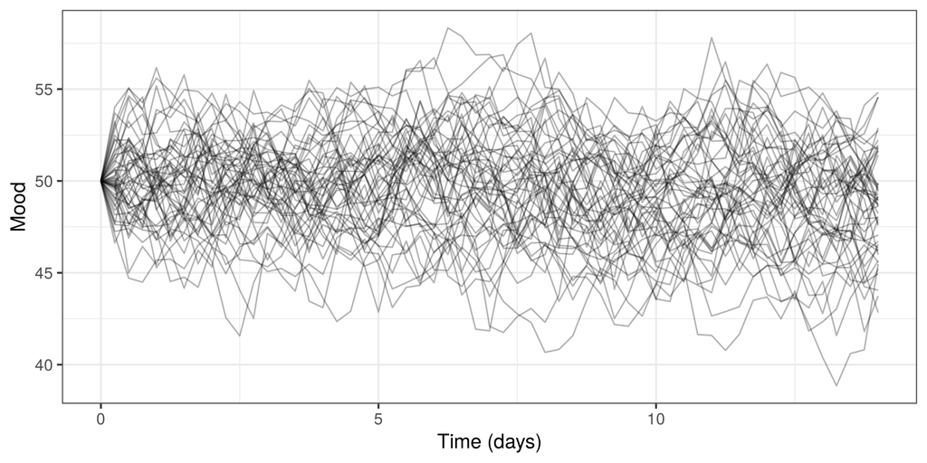

```r
ggplot(dat, aes(x = time, y = Mood, group = id)) +
  geom_line(alpha = 0.3) +
  theme_bw(base_size = 14) +
  labs(x = "Time (days)", y = "Mood")
```

`rbind()` in a loop gets slow for thousands of people. For a few hundred it is fine. For more, store each person in a list and bind once at the end: `simList[[person]] <- ...` in the loop, then `dat <- do.call(rbind, simList)`.

## 3.2 How do I make people differ in where they rest?

Draw a resting level per person, `level <- rnorm(1, levelTypical, levelSD)`, and compute that person’s `B <- -A * level`.

Keep a separate data frame `people` with one row per person and their true parameters. You will need it to plot and to check estimates later.

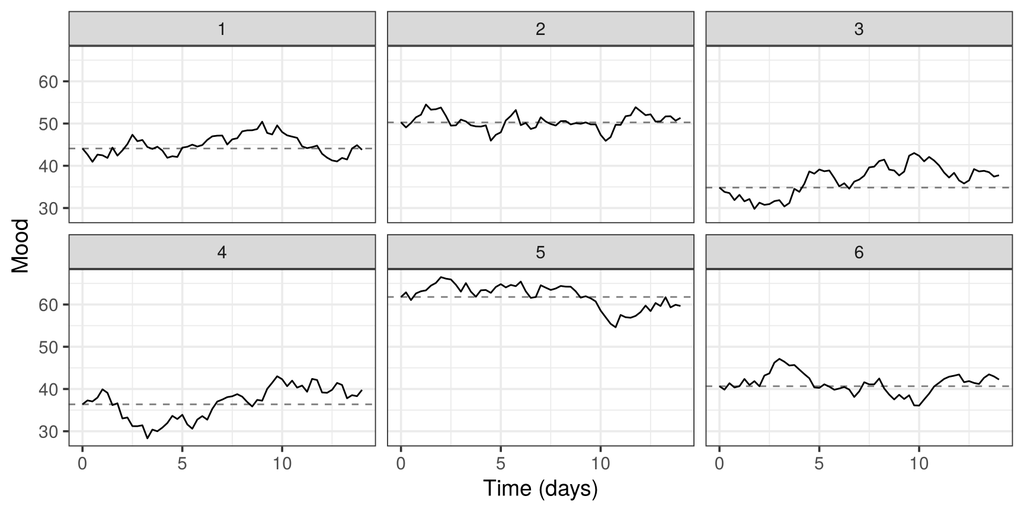

```r
library(ggplot2)

Npeople <- 6
times <- seq(from = 0, to = 14, by = 0.25)
Nsteps <- 20
A <- -0.5
G <- 3
levelTypical <- 50                # <-- NEW: resting level of the typical person
levelSD <- 10                     # <-- NEW: how much people differ in resting level

simulateMood <- function(A, B, G, initialMood, times, Nsteps){
  Nobs <- length(times)
  Mood <- rep(NA, Nobs)
  MoodState <- initialMood
  for(i in 1:Nobs){
    if(i > 1){
      dt <- (times[i] - times[i-1]) / Nsteps
      for(stepi in 1:Nsteps){
        dMood <- A*MoodState + B
        kick <- G * sqrt(dt) * rnorm(1)
        MoodState <- MoodState + dMood * dt + kick
      }
    }
    Mood[i] <- MoodState
  }
  data.frame(time = times, Mood = Mood)
}

set.seed(11)
people <- data.frame(id = 1:Npeople)
people$level <- rnorm(Npeople, mean = levelTypical, sd = levelSD)   # <-- NEW: one level per person
people$B <- -A * people$level   # <-- NEW: the B that goes with it

dat <- NULL
for (i in 1:Npeople) {
  sim <- simulateMood(A, B = people$B[i], G, initialMood = people$level[i],   # start at own level
                      times = times, Nsteps = Nsteps)
  dat <- rbind(dat, data.frame(id = i, sim))
}

ggplot(dat, aes(x = time, y = Mood)) +
  geom_hline(data = people, aes(yintercept = level), linetype = "dashed", colour = "grey50") +
  geom_line() +
  facet_wrap(~ id) +
  theme_bw(base_size = 14) +
  labs(x = "Time (days)", y = "Mood")
```

## 3.3 How do I make people differ in how fast they return (A)?

Multiply the typical `A` by a positive person factor: `A_i <- Atypical * exp(rnorm(1, 0, Asd))`. `exp()` is always positive, so every `A_i` stays negative. Then set `B_i <- -A_i * level` so the resting level does not move.

If you would *add* a normal difference to `A`, some people could get a positive `A`, and their mood would run away. `Asd = 0.6` means people’s `A` typically differs by a factor of about `exp(0.6) = 1.8` from the typical value.

```r
library(ggplot2)

Npeople <- 6
times <- seq(from = 0, to = 14, by = 0.25)
Nsteps <- 20
level <- 50
G <- 3
Atypical <- -0.5                  # <-- NEW: A of the typical person
Asd <- 0.6                        # <-- NEW: spread of A, on the log scale

simulateMood <- function(A, B, G, initialMood, times, Nsteps){
  Nobs <- length(times)
  Mood <- rep(NA, Nobs)
  MoodState <- initialMood
  for(i in 1:Nobs){
    if(i > 1){
      dt <- (times[i] - times[i-1]) / Nsteps
      for(stepi in 1:Nsteps){
        dMood <- A*MoodState + B
        kick <- G * sqrt(dt) * rnorm(1)
        MoodState <- MoodState + dMood * dt + kick
      }
    }
    Mood[i] <- MoodState
  }
  data.frame(time = times, Mood = Mood)
}

set.seed(12)
people <- data.frame(id = 1:Npeople)
people$A <- Atypical * exp(rnorm(Npeople, mean = 0, sd = Asd))   # <-- NEW: always negative
people$B <- -people$A * level   # <-- NEW: everyone rests at 50
people$halfLife <- log(2) / -people$A   # days until half of a deviation is gone
people$label <- paste0("A = ", round(people$A, 2), ", half-life ", round(people$halfLife, 1), " d")
round(people[, c("A", "B", "halfLife")], 2)
```

```
##       A     B halfLife
## 1 -0.21 10.28     3.37
## 2 -1.29 64.40     0.54
## 3 -0.28 14.08     2.46
## 4 -0.29 14.39     2.41
## 5 -0.15  7.54     4.60
## 6 -0.42 21.23     1.63
```

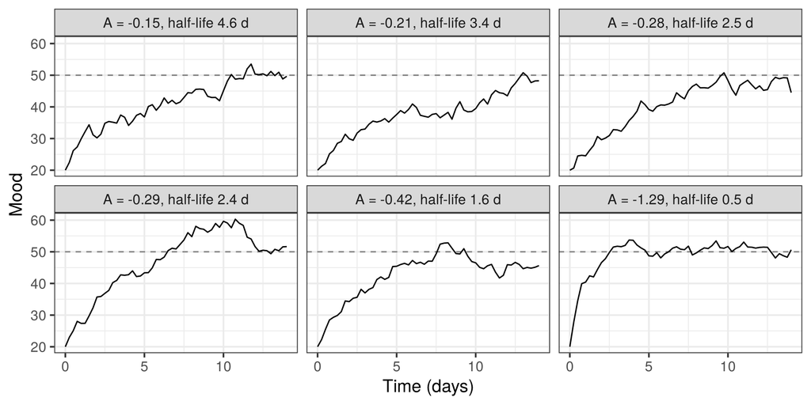

```r
dat <- NULL
for (i in 1:Npeople) {
  sim <- simulateMood(A = people$A[i], B = people$B[i], G, initialMood = 20,   # everyone starts low
                      times = times, Nsteps = Nsteps)
  dat <- rbind(dat, data.frame(id = i, label = people$label[i], sim))
}

ggplot(dat, aes(x = time, y = Mood)) +
  geom_hline(yintercept = level, linetype = "dashed", colour = "grey50") +
  geom_line() +
  facet_wrap(~ label) +
  theme_bw(base_size = 14) +
  labs(x = "Time (days)", y = "Mood")
```

With the same `G`, people with `A` close to 0 also fluctuate **more** (long-run SD `G / sqrt(2 * -A)`). If you want people to differ in speed only, not in how much they fluctuate, set `G_i <- sdTarget * sqrt(2 * -A_i)` for one chosen `sdTarget`.

## 3.4 How do I make people differ in how hard they are kicked (G)?

The same trick as for `A`: `G_i <- Gtypical * exp(rnorm(1, 0, Gsd))`, so every `G_i` stays positive.

```r
library(ggplot2)

Npeople <- 6
times <- seq(from = 0, to = 56, by = 0.25)   # 8 weeks, so the SDs can be compared
Nsteps <- 20
A <- -0.5
level <- 50
B <- -A * level
Gtypical <- 4                     # <-- NEW: G of the typical person
Gsd <- 0.5                        # <-- NEW: spread of G, on the log scale

simulateMood <- function(A, B, G, initialMood, times, Nsteps){
  Nobs <- length(times)
  Mood <- rep(NA, Nobs)
  MoodState <- initialMood
  for(i in 1:Nobs){
    if(i > 1){
      dt <- (times[i] - times[i-1]) / Nsteps
      for(stepi in 1:Nsteps){
        dMood <- A*MoodState + B
        kick <- G * sqrt(dt) * rnorm(1)
        MoodState <- MoodState + dMood * dt + kick
      }
    }
    Mood[i] <- MoodState
  }
  data.frame(time = times, Mood = Mood)
}

set.seed(13)
people <- data.frame(id = 1:Npeople)
people$G <- Gtypical * exp(rnorm(Npeople, mean = 0, sd = Gsd))   # <-- NEW: always positive
people$longRunSD <- people$G / sqrt(2 * -A)
people$label <- paste0("G = ", round(people$G, 1))

dat <- NULL
for (i in 1:Npeople) {
  sim <- simulateMood(A, B, G = people$G[i], initialMood = level, times = times, Nsteps = Nsteps)
  dat <- rbind(dat, data.frame(id = i, label = people$label[i], sim))
}

# the SD of each person's ratings is roughly their long-run SD (8 weeks is still short)
data.frame(people[, c("G", "longRunSD")],
           observedSD = tapply(dat$Mood, dat$id, sd))
```

```
##          G longRunSD observedSD
## 1 5.277528  5.277528   4.009765
## 2 3.476960  3.476960   3.087639
## 3 9.716991  9.716991   8.452816
## 4 4.392745  4.392745   4.498782
## 5 7.082008  7.082008   6.526947
## 6 4.923686  4.923686   5.457809
```

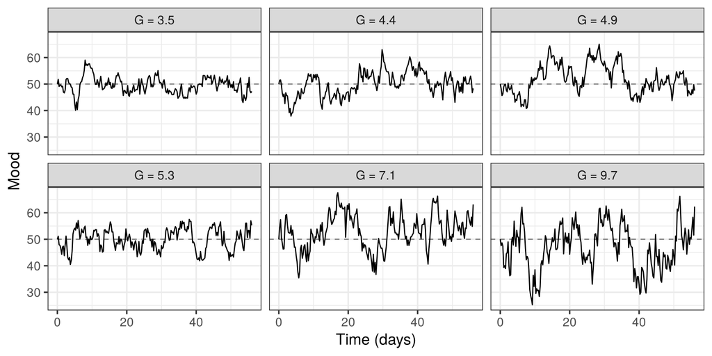

```r
ggplot(dat, aes(x = time, y = Mood)) +
  geom_hline(yintercept = level, linetype = "dashed", colour = "grey50") +
  geom_line() +
  facet_wrap(~ label) +
  theme_bw(base_size = 14) +
  labs(x = "Time (days)", y = "Mood")
```

## 3.5 How do I make two person differences go together (correlated)?

Draw two standard normal numbers per person and mix them: `z1 <- rnorm(1)`, `z2 <- rho * z1 + sqrt(1 - rho^2) * rnorm(1)`. Then use `z1` for one parameter and `z2` for the other. Their correlation is `rho`.

Example: people with a lower resting level also return more slowly (`A` closer to 0). The same trick can make a starting level and a change per week correlate in a two-level model (Many clients).

```r
library(ggplot2)

Npeople <- 200
levelTypical <- 50; levelSD <- 10
Atypical <- -0.5; Asd <- 0.4
rho <- 0.6   # <-- NEW: correlation between the two person differences
                                  # positive: higher level goes with larger z2, so a stronger (more negative) A

set.seed(14)
z1 <- rnorm(Npeople)                                       # <-- NEW
z2 <- rho * z1 + sqrt(1 - rho^2) * rnorm(Npeople)   # <-- NEW: correlates rho with z1

people <- data.frame(id = 1:Npeople)
people$level <- levelTypical + levelSD * z1
people$A <- Atypical * exp(Asd * z2)        # large z2: A further from 0 (faster return)
people$B <- -people$A * people$level
people$halfLife <- log(2) / -people$A

cor(z1, z2)                                  # close to rho
```

```
## [1] 0.5122032
```

```r
cor(people$level, people$halfLife)           # lower level goes with a longer half-life
```

```
## [1] -0.5077004
```

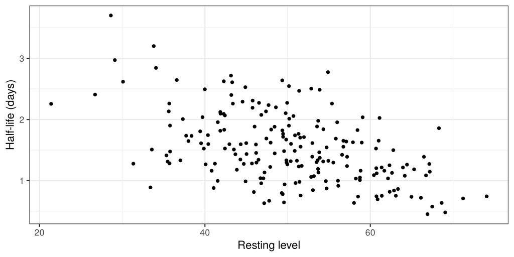

```r
ggplot(people, aes(x = level, y = halfLife)) +
  geom_point() +
  theme_bw(base_size = 14) +
  labs(x = "Resting level", y = "Half-life (days)")
```

Simulate each person’s mood exactly as in How fast they return, with `A = people$A[i]` and `B = people$B[i]`.

## 3.6 How do I let a trait (e.g. neuroticism) predict people’s parameters?

Draw the trait per person, then let it shift each parameter: `level_i <- levelTypical + levelEffectN * N_i + rnorm(1, 0, levelSD)`, `A_i <- Atypical * exp(AeffectN * N_i) * exp(rnorm(1, 0, Asd))`, and the same for `G_i`.

The trait is measured once and does not change over time (a time-independent predictor). Set an `...effectN` to 0 to switch off the effect on that parameter, and an `...SD` to 0 to make the trait the only reason people differ.

```r
library(ggplot2)

Npeople <- 50
times <- seq(from = 0, to = 28, by = 0.25)
Nsteps <- 20

levelTypical <- 50; levelEffectN <- -8;  levelSD <- 6   # <-- NEW: 1 SD neuroticism, level 8 lower
Atypical <- -0.5;   AeffectN <- -0.5;    Asd <- 0.3   # <-- NEW: 1 SD neuroticism, A x 0.61 (slower)
# <-- NEW: 1 SD neuroticism, G x 1.22 (stronger kicks)
Gtypical <- 3;      GeffectN <- 0.2;     Gsd <- 0.25

simulateMood <- function(A, B, G, initialMood, times, Nsteps){
  Nobs <- length(times)
  Mood <- rep(NA, Nobs)
  MoodState <- initialMood
  for(i in 1:Nobs){
    if(i > 1){
      dt <- (times[i] - times[i-1]) / Nsteps
      for(stepi in 1:Nsteps){
        dMood <- A*MoodState + B
        kick <- G * sqrt(dt) * rnorm(1)
        MoodState <- MoodState + dMood * dt + kick
      }
    }
    Mood[i] <- MoodState
  }
  data.frame(time = times, Mood = Mood)
}

set.seed(15)
people <- data.frame(id = 1:Npeople)
people$N <- rnorm(Npeople)   # <-- NEW: trait (z-score)
people$level <- levelTypical + levelEffectN * people$N + rnorm(Npeople, 0, levelSD)
people$A <- Atypical * exp(AeffectN * people$N) * exp(rnorm(Npeople, 0, Asd))
people$G <- Gtypical * exp(GeffectN * people$N) * exp(rnorm(Npeople, 0, Gsd))
people$B <- -people$A * people$level

dat <- NULL
for (i in 1:Npeople) {
  sim <- simulateMood(A = people$A[i], B = people$B[i], G = people$G[i],
                      initialMood = people$level[i], times = times, Nsteps = Nsteps)
  dat <- rbind(dat, data.frame(id = i, Neuroticism = people$N[i], sim))
}

# summaries per person, against neuroticism
perPerson <- data.frame(id = 1:Npeople, Neuroticism = people$N,
                        mean = tapply(dat$Mood, dat$id, mean),
                        SD = tapply(dat$Mood, dat$id, sd))
round(cor(perPerson[, -1]), 2)
```

```
##             Neuroticism  mean    SD
## Neuroticism        1.00 -0.69  0.69
## mean              -0.69  1.00 -0.37
## SD                 0.69 -0.37  1.00
```

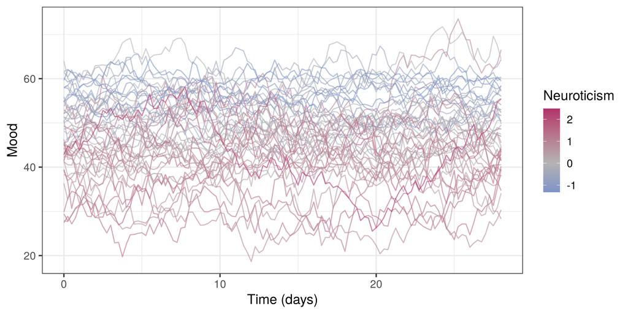

```r
ggplot(dat, aes(x = time, y = Mood, group = id, colour = Neuroticism)) +
  geom_line(alpha = 0.6) +
  scale_colour_gradient2(low = "#2a78d6", mid = "grey70", high = "#b0306a", midpoint = 0) +
  theme_bw(base_size = 14) +
  labs(x = "Time (days)", y = "Mood")
```

## 3.7 How do I simulate two groups, for example treatment and control?

Give every person a `group` and let the group decide a parameter or an input. Here the treatment group gets a therapy push from day 7 on: `dMood <- A*MoodState + B + therapy * treated * therapyOn`.

Groups are a person-level predictor with two values. You can let the group change any parameter, for example `A` (`A_i <- Atypical * exp(Aeffect * treated)`). Here therapy is an extra push that is switched on at a certain time (see Switch a push on).

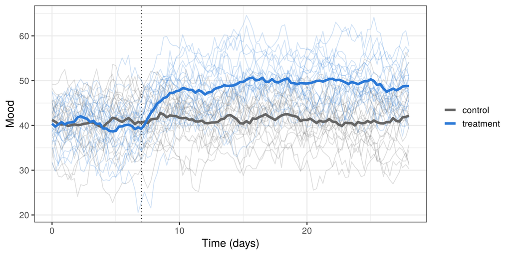

```r
library(ggplot2)

Npeople <- 40
times <- seq(from = 0, to = 28, by = 0.25)
Nsteps <- 20
A <- -0.5
G <- 4
levelTypical <- 40; levelSD <- 5
therapy <- 5                      # <-- NEW: push of therapy (mood units per day)
therapyStart <- 7                 # <-- NEW: therapy starts on day 7

simulateMood <- function(A, B, G, initialMood, times, Nsteps, treated){
  Nobs <- length(times)
  Mood <- rep(NA, Nobs)
  MoodState <- initialMood
  for(i in 1:Nobs){
    if(i > 1){
      dt <- (times[i] - times[i-1]) / Nsteps
      for(stepi in 1:Nsteps){
        tNow <- times[i-1] + (stepi - 1) * dt   # <-- NEW: current time
        therapyOn <- as.numeric(tNow >= therapyStart)   # <-- NEW: 0 before, 1 after
        # <-- CHANGE: push only if treated
        dMood <- A*MoodState + B + therapy * treated * therapyOn
        kick <- G * sqrt(dt) * rnorm(1)
        MoodState <- MoodState + dMood * dt + kick
      }
    }
    Mood[i] <- MoodState
  }
  data.frame(time = times, Mood = Mood)
}

set.seed(16)
people <- data.frame(id = 1:Npeople,
                     group = rep(c("control", "treatment"), each = Npeople / 2))   # <-- NEW
people$treated <- as.numeric(people$group == "treatment")
people$level <- rnorm(Npeople, levelTypical, levelSD)
people$B <- -A * people$level

dat <- NULL
for (i in 1:Npeople) {
  sim <- simulateMood(A, B = people$B[i], G, initialMood = people$level[i],
                      times = times, Nsteps = Nsteps, treated = people$treated[i])
  dat <- rbind(dat, data.frame(id = i, group = people$group[i], sim))
}

groupMeans <- aggregate(Mood ~ time + group, data = dat, FUN = mean)

ggplot(dat, aes(x = time, y = Mood, colour = group)) +
  geom_vline(xintercept = therapyStart, linetype = "dotted") +
  geom_line(aes(group = id), alpha = 0.2) +
  geom_line(data = groupMeans, linewidth = 1.5) +
  scale_colour_manual(values = c(control = "grey40", treatment = "#2a78d6")) +
  theme_bw(base_size = 14) +
  labs(x = "Time (days)", y = "Mood", colour = NULL)
```

# 4 Discrete-time recipes

These models count **ratings** instead of running in continuous time: each rating is computed from the one before (or from the week number), with no small steps in between. They are useful as a comparison, and for simulating data that a discrete-time analysis (regression, cross-lagged panel model) would expect.

## 4.1 How do I simulate a straight line plus independent weekly shocks?

`mood <- rnorm(21, mean = b0 + b1 * week, sd = sigma)` for weeks 0 to 20.

$Mood_t = \beta_0 + \beta_1 t + \varepsilon_t$, with $\varepsilon_t \sim N(0, \sigma)$, independent from week to week. Because the shocks are independent, one `rnorm()` call is enough. The loop version below does exactly the same, and is easier to change later.

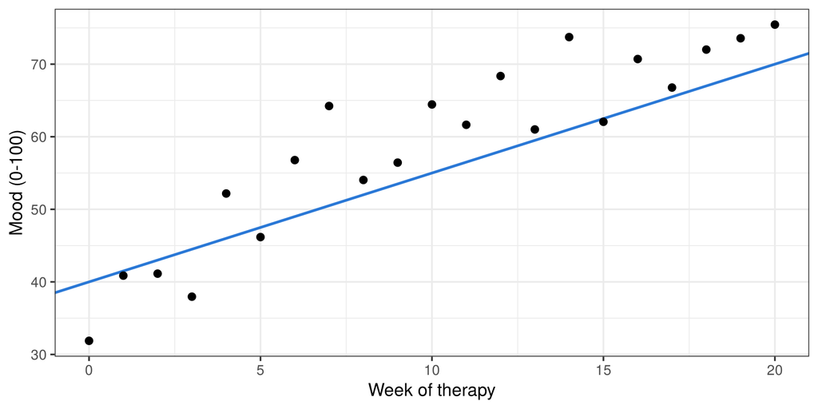

```r
library(ggplot2)

week <- 0:20                      # weekly ratings
b0 <- 40                          # expected mood at intake
b1 <- 1.5                         # change per week
sigma <- 8                        # size of the weekly shocks

set.seed(17)
mood <- rnorm(length(week), mean = b0 + b1 * week, sd = sigma)   # one line

# the same story as a loop: one week at a time
moodLoop <- rep(NA, length(week))
for (t in seq_along(week)) {
  expected <- b0 + b1 * week[t]               # where therapy has brought him
  shock <- rnorm(1, mean = 0, sd = sigma)     # what life did this week
  moodLoop[t] <- expected + shock
}

albert <- data.frame(week = week, mood = mood)
ggplot(albert, aes(x = week, y = mood)) +
  geom_abline(intercept = b0, slope = b1, colour = "#2a78d6", linewidth = 1) +
  geom_point(size = 2.5) +
  theme_bw(base_size = 14) +
  labs(x = "Week of therapy", y = "Mood (0-100)")
```

## 4.2 How do I simulate many clients, each with their own line?

Draw an intercept and slope per client (level 2), then simulate each client’s weeks (level 1): `b0_i <- g00 + tau0 * z0`, `b1_i <- g10 + tau1 * z1`.

```r
library(ggplot2)

Nclients <- 30
week <- 0:20
g00 <- 40; g10 <- 1.0             # typical intercept and slope
tau0 <- 7; tau1 <- 0.5            # how much clients differ in intercept and slope
rho <- -0.3                       # correlation between intercept and slope
sigma <- 8                        # weekly shocks within a client

set.seed(18)
z0 <- rnorm(Nclients)
z1 <- rho * z0 + sqrt(1 - rho^2) * rnorm(Nclients)
clients <- data.frame(client = 1:Nclients,
                      b0 = g00 + tau0 * z0,       # level 2: each client's own line
                      b1 = g10 + tau1 * z1)

clinic <- NULL
for (i in 1:Nclients) {
  mood <- rnorm(length(week), mean = clients$b0[i] + clients$b1[i] * week, sd = sigma)  # level 1
  clinic <- rbind(clinic, data.frame(client = i, week = week, mood = mood))
}
head(clinic)
```

```
##   client week     mood
## 1      1    0 39.72289
## 2      1    1 48.79235
## 3      1    2 35.66247
## 4      1    3 47.99296
## 5      1    4 42.79747
## 6      1    5 52.95872
```

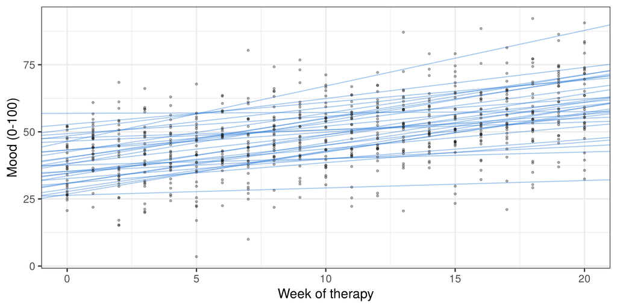

```r
ggplot(clinic, aes(x = week, y = mood, group = client)) +
  geom_abline(data = clients, aes(intercept = b0, slope = b1), colour = "#2a78d6", alpha = 0.4) +
  geom_point(alpha = 0.3, size = 0.8) +
  theme_bw(base_size = 14) +
  labs(x = "Week of therapy", y = "Mood (0-100)")
```

To let clients drop out early, keep only each client’s first `n_i` weeks: `clinic <- clinic[clinic$week < nWeeks[clinic$client], ]` with `nWeeks <- sample(4:21, Nclients, replace = TRUE)`.

## 4.3 How do I simulate an autoregressive AR(1) process?

`mood[t] <- mu + phi * (mood[t-1] - mu) + rnorm(1, 0, sigma)`, for one rating after the other.

`phi` is the share of the last deviation that is still there at the next rating. `-1 < phi < 1` keeps the process around `mu`. Starting at a draw from the long-run distribution (SD `sigma / sqrt(1 - phi^2)`) avoids a warm-up.

```r
library(ggplot2)

n <- 200                          # number of ratings
mu <- 50                          # usual level
phi <- 0.6                        # carry-over from one rating to the next
sigma <- 8                        # size of each new shock

set.seed(19)
mood <- rep(NA, n)
mood[1] <- mu + rnorm(1, 0, sigma / sqrt(1 - phi^2))   # start in the long-run distribution
for (t in 2:n) {
  mood[t] <- mu + phi * (mood[t-1] - mu) + rnorm(1, 0, sigma)
}

cor(mood[-1], mood[-n])   # roughly phi (short series give slightly lower values)
```

```
## [1] 0.5251799
```

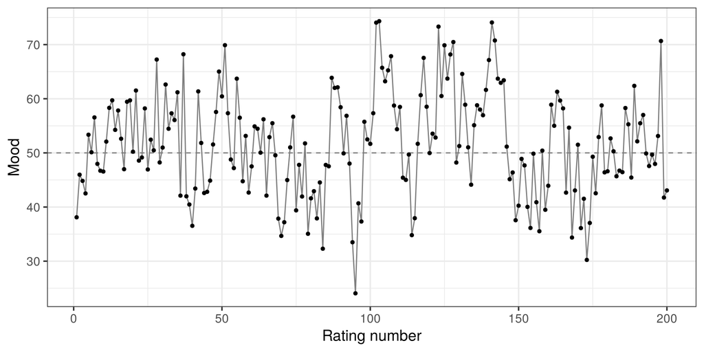

```r
ggplot(data.frame(rating = 1:n, mood = mood), aes(x = rating, y = mood)) +
  geom_hline(yintercept = mu, linetype = "dashed", colour = "grey50") +
  geom_line(colour = "grey50") + geom_point(size = 1.2) +
  theme_bw(base_size = 14) +
  labs(x = "Rating number", y = "Mood")
```

## 4.4 How do I simulate a cross-lagged VAR(1) process?

One line per variable, each computed from **both** variables at the previous rating: `act[t] <- muAct + phiAA*(act[t-1] - muAct) + phiAM*(mood[t-1] - muMood) + rnorm(1, 0, sigma)` and the same for `mood[t]`.

The autoregressive effects (`phiAA`, `phiMM`) are each variable’s own carry-over; the cross-lagged effects (`phiMA`: activity yesterday -> mood today, `phiAM`: mood yesterday -> activity today) carry one variable into the other. Compute both lines from yesterday’s values before moving on. A third variable gets its own line and one more term in every line, as in A third construct.

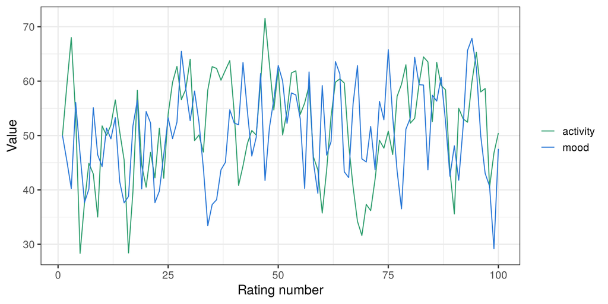

```r
library(ggplot2)

n <- 100
muAct <- 50; muMood <- 50         # usual levels
phiAA <- 0.4                      # activity yesterday -> activity today
phiAM <- 0.0                      # mood yesterday     -> activity today
phiMA <- 0.3                      # activity yesterday -> mood today
phiMM <- 0.4                      # mood yesterday     -> mood today
sigma <- 8                        # SD of the new shocks
# if the series explode, the carry-over effects are too large together: make them smaller

set.seed(20)
act <- mood <- rep(NA, n)
act[1] <- muAct; mood[1] <- muMood
for (t in 2:n) {
  act[t]  <- muAct  + phiAA*(act[t-1] - muAct) + phiAM*(mood[t-1] - muMood) + rnorm(1, 0, sigma)
  mood[t] <- muMood + phiMA*(act[t-1] - muAct) + phiMM*(mood[t-1] - muMood) + rnorm(1, 0, sigma)
}

dat <- data.frame(rating = rep(1:n, 2),
                  value = c(act, mood),
                  variable = rep(c("activity", "mood"), each = n))
ggplot(dat, aes(x = rating, y = value, colour = variable)) +
  geom_line() +
  scale_colour_manual(values = c(activity = "#2f9e6e", mood = "#2a78d6")) +
  theme_bw(base_size = 14) +
  labs(x = "Rating number", y = "Value", colour = NULL)
```

## 4.5 Which discrete-time effect does my continuous-time model imply?

For one construct: $\phi(\Delta t) = e^{A\,\Delta t}$, in R `exp(A * deltaT)`. For coupled constructs: start everything at rest, nudge one construct by +1, simulate without kicks, and read off how far each construct is from rest after $\Delta t$.

This is how a continuous-time model and a discrete-time model are linked. The “nudge” works for any linear model, also with three or more constructs.

```r
library(ggplot2)

# --- one construct: the AR coefficient for different intervals -------------
A <- -0.5
deltaT <- c(0.25, 1, 7)                                   # 6 hours, 1 day, 1 week
data.frame(interval = deltaT, phi = round(exp(A * deltaT), 3))
```

```
##   interval   phi
## 1     0.25 0.882
## 2     1.00 0.607
## 3     7.00 0.030
```

```r
# --- two coupled constructs: the cross-lagged effect by a nudge --------------
A1 <- -0.6; A2 <- -0.4            # own pull of Albert and the rabbit
A12 <- 1; A21 <- 0                # the rabbit drives Albert
rest <- c(5, 5)
B1 <- -(A1*rest[1] + A12*rest[2]); B2 <- -(A21*rest[1] + A2*rest[2])

times <- seq(from = 0, to = 14, by = 0.025)
Nsteps <- 10
albert <- rabbit <- rep(NA, length(times))
albertState <- rest[1]            # Albert at rest
rabbitState <- rest[2] + 1        # the rabbit nudged by +1
albert[1] <- albertState; rabbit[1] <- rabbitState
for (i in 2:length(times)) {
  dt <- (times[i] - times[i-1]) / Nsteps
  for (stepi in 1:Nsteps) {
    dAlbert <- A1*albertState + A12*rabbitState + B1
    dRabbit <- A21*albertState + A2*rabbitState + B2
    albertState <- albertState + dAlbert * dt
    rabbitState <- rabbitState + dRabbit * dt
  }
  albert[i] <- albertState; rabbit[i] <- rabbitState
}
nudge <- data.frame(interval = times,
                    # effect of the rabbit on Albert after this interval
                    crossLagged = albert - rest[1],
                    autoRabbit = rabbit - rest[2])    # the rabbit's own carry-over

nudge[round(nudge$interval, 8) %in% c(0.125, 1, 2, 7), ]
```

```
##     interval crossLagged autoRabbit
## 6      0.125   0.1175719 0.95120563
## 41     1.000   0.6081071 0.67018591
## 81     2.000   0.7411308 0.44914915
## 281    7.000   0.2288828 0.06072493
```

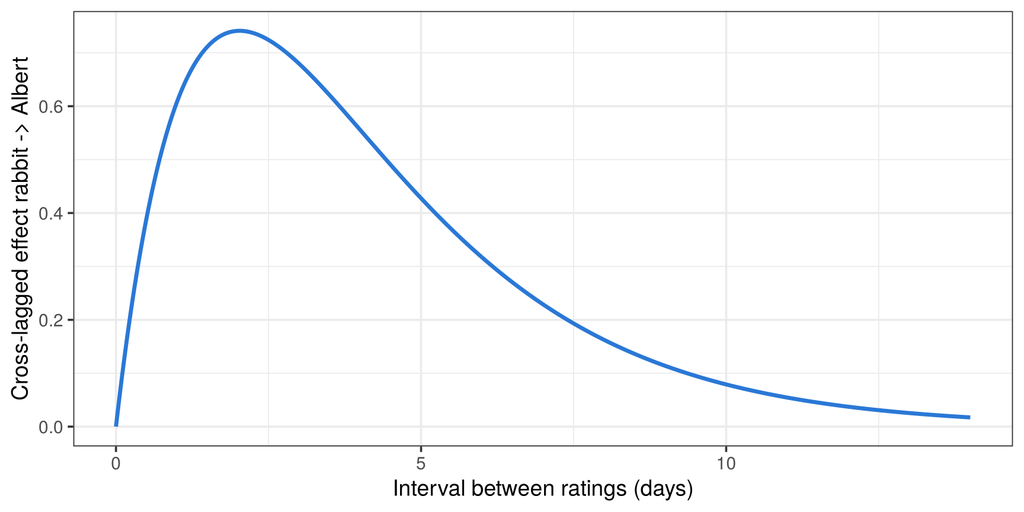

```r
ggplot(nudge, aes(x = interval, y = crossLagged)) +
  geom_line(linewidth = 1.2, colour = "#2a78d6") +
  theme_bw(base_size = 14) +
  labs(x = "Interval between ratings (days)", y = "Cross-lagged effect rabbit -> Albert")
```

# 5 Inputs that change over time

## 5.1 How do I switch a push on at a certain time, e.g. when therapy starts?

Inside the small-step loop, compute the current time and a switch: `tNow <- times[i-1] + (stepi - 1) * dt`, `therapyOn <- as.numeric(tNow >= therapyStart)`. Add the push to the slope: `dMood <- A*(MoodState - baseline) + therapy * therapyOn`.

Written with a personal baseline: $\frac{dMood}{dt} = A\,(Mood - \mu) + T \cdot therapyOn(t)$. Without therapy mood rests at its baseline $\mu$; during therapy it moves towards $\mu + T/(-A)$. The switch is checked in every small step, so therapy can start at any moment, also between two ratings.

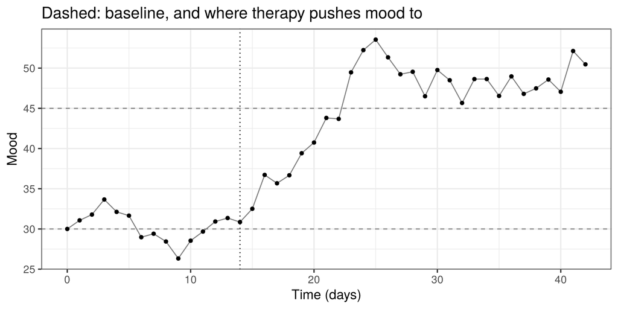

```r
library(ggplot2)

times <- seq(from = 0, to = 42, by = 1)    # one rating a day for 6 weeks
Nsteps <- 20
A <- -0.2
baseline <- 30
G <- 2
therapy <- 3                               # <-- NEW: push (mood units per day)
therapyStart <- 14                         # <-- NEW: therapy starts on day 14

simulateMood <- function(A, baseline, G, initialMood, times, Nsteps){
  Nobs <- length(times)
  Mood <- rep(NA, Nobs)
  MoodState <- initialMood
  for(i in 1:Nobs){
    if(i > 1){
      dt <- (times[i] - times[i-1]) / Nsteps
      for(stepi in 1:Nsteps){
        tNow <- times[i-1] + (stepi - 1) * dt   # <-- NEW: time of this small step
        therapyOn <- as.numeric(tNow >= therapyStart)   # <-- NEW: 0 before, 1 from the start
        # <-- CHANGE: pull to baseline + push
        dMood <- A*(MoodState - baseline) + therapy * therapyOn
        kick <- G * sqrt(dt) * rnorm(1)
        MoodState <- MoodState + dMood * dt + kick
      }
    }
    Mood[i] <- MoodState
  }
  data.frame(time = times, Mood = Mood)
}

set.seed(21)
albert <- simulateMood(A, baseline, G, initialMood = baseline, times = times, Nsteps = Nsteps)

ggplot(albert, aes(x = time, y = Mood)) +
  geom_vline(xintercept = therapyStart, linetype = "dotted") +
  geom_hline(yintercept = c(baseline, baseline + therapy / -A), linetype = "dashed", colour = "grey50") +
  geom_line(colour = "grey50") + geom_point() +
  theme_bw(base_size = 14) +
  labs(x = "Time (days)", y = "Mood",
       title = "Dashed: baseline, and where therapy pushes mood to")
```

## 5.2 How do I switch the push off again, e.g. when therapy ends?

Make the switch 1 only between start and end: `therapyOn <- as.numeric(tNow >= therapyStart & tNow < therapyEnd)`.

After the end, the rule is the same as before the start, but mood is no longer at its baseline, so it falls back. In this model gains last only as long as therapy does.

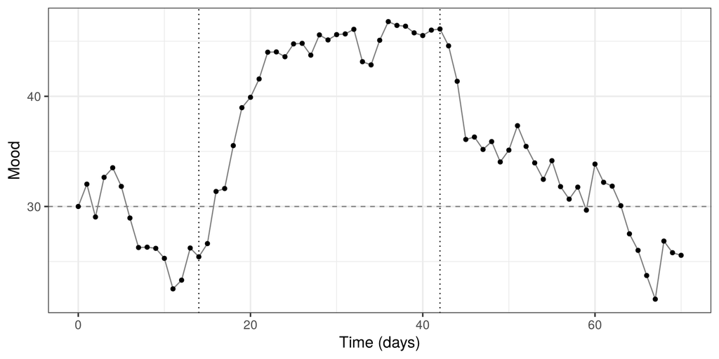

```r
library(ggplot2)

times <- seq(from = 0, to = 70, by = 1)
Nsteps <- 20
A <- -0.2
baseline <- 30
G <- 2
therapy <- 3
therapyStart <- 14
therapyEnd <- 42                           # <-- NEW: therapy ends on day 42

simulateMood <- function(A, baseline, G, initialMood, times, Nsteps){
  Nobs <- length(times)
  Mood <- rep(NA, Nobs)
  MoodState <- initialMood
  for(i in 1:Nobs){
    if(i > 1){
      dt <- (times[i] - times[i-1]) / Nsteps
      for(stepi in 1:Nsteps){
        tNow <- times[i-1] + (stepi - 1) * dt
        # <-- CHANGE: on, then off
        therapyOn <- as.numeric(tNow >= therapyStart & tNow < therapyEnd)
        dMood <- A*(MoodState - baseline) + therapy * therapyOn
        kick <- G * sqrt(dt) * rnorm(1)
        MoodState <- MoodState + dMood * dt + kick
      }
    }
    Mood[i] <- MoodState
  }
  data.frame(time = times, Mood = Mood)
}

set.seed(22)
albert <- simulateMood(A, baseline, G, initialMood = baseline, times = times, Nsteps = Nsteps)

ggplot(albert, aes(x = time, y = Mood)) +
  geom_vline(xintercept = c(therapyStart, therapyEnd), linetype = "dotted") +
  geom_hline(yintercept = baseline, linetype = "dashed", colour = "grey50") +
  geom_line(colour = "grey50") + geom_point() +
  theme_bw(base_size = 14) +
  labs(x = "Time (days)", y = "Mood")
```

Use the time at the **start** of the small step, `(stepi - 1) * dt`, and `>=` for the start and `<` for the end. Then a therapy from day 14 to day 42 is on for exactly 28 days, whatever `Nsteps` is.

## 5.3 How do I let therapy move the baseline itself, so gains last?

Make the baseline a **second state** that changes during therapy: `dBaseline <- learning * therapyOn`, and update it in every small step next to `MoodState`. Mood is pulled towards the *current* baseline.

$\frac{dMood}{dt} = A\,(Mood - \mu(t)) + T \cdot therapyOn$ and $\frac{d\mu}{dt} = c \cdot therapyOn$. After therapy, mood returns to the new, higher baseline.

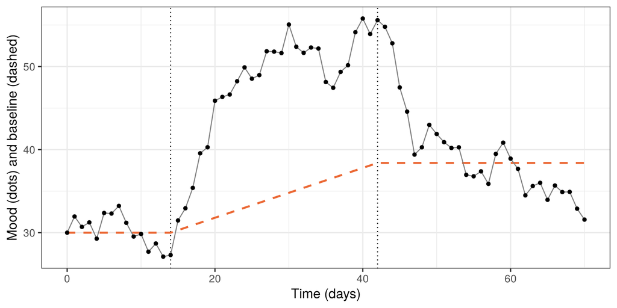

```r
library(ggplot2)

times <- seq(from = 0, to = 70, by = 1)
Nsteps <- 20
A <- -0.2
G <- 2
therapy <- 3
therapyStart <- 14
therapyEnd <- 42
learning <- 0.3   # <-- NEW: how fast therapy moves the baseline (per day)

simulateMood <- function(A, baseline, G, initialMood, times, Nsteps){
  Nobs <- length(times)
  Mood <- Baseline <- rep(NA, Nobs)
  MoodState <- initialMood
  BaselineState <- baseline   # <-- NEW: the baseline is a state
  for(i in 1:Nobs){
    if(i > 1){
      dt <- (times[i] - times[i-1]) / Nsteps
      for(stepi in 1:Nsteps){
        tNow <- times[i-1] + (stepi - 1) * dt
        therapyOn <- as.numeric(tNow >= therapyStart & tNow < therapyEnd)
        # <-- CHANGE: current baseline
        dMood <- A*(MoodState - BaselineState) + therapy * therapyOn
        dBaseline <- learning * therapyOn                               # <-- NEW
        kick <- G * sqrt(dt) * rnorm(1)
        MoodState <- MoodState + dMood * dt + kick
        BaselineState <- BaselineState + dBaseline * dt                 # <-- NEW
      }
    }
    Mood[i] <- MoodState
    Baseline[i] <- BaselineState
  }
  data.frame(time = times, Mood = Mood, Baseline = Baseline)
}

set.seed(23)
albert <- simulateMood(A, baseline = 30, G, initialMood = 30, times = times, Nsteps = Nsteps)

ggplot(albert, aes(x = time)) +
  geom_vline(xintercept = c(therapyStart, therapyEnd), linetype = "dotted") +
  geom_line(aes(y = Baseline), linetype = "dashed", linewidth = 1, colour = "#eb6834") +
  geom_line(aes(y = Mood), colour = "grey50") + geom_point(aes(y = Mood)) +
  theme_bw(base_size = 14) +
  labs(x = "Time (days)", y = "Mood (dots) and baseline (dashed)")
```

## 5.4 How do I add a steady trend, like a straight line?

Let the baseline rise at a constant rate the whole time: `dBaseline <- trend`. Mood is pulled towards a baseline that keeps moving.

This is the continuous-time version of a straight line plus shocks (Straight line), but now the shocks carry over. Mood lags behind the moving baseline by `trend / -A`: it is always chasing it.

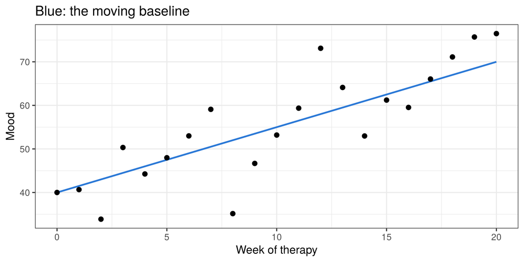

```r
library(ggplot2)

times <- seq(from = 0, to = 140, by = 7)   # weekly ratings for 20 weeks (time in days)
Nsteps <- 70
A <- -0.5
G <- 8
trend <- 1.5 / 7                  # <-- NEW: baseline rises 1.5 points per week

simulateMood <- function(A, baseline, G, initialMood, times, Nsteps){
  Nobs <- length(times)
  Mood <- Baseline <- rep(NA, Nobs)
  MoodState <- initialMood
  BaselineState <- baseline
  for(i in 1:Nobs){
    if(i > 1){
      dt <- (times[i] - times[i-1]) / Nsteps
      for(stepi in 1:Nsteps){
        dMood <- A*(MoodState - BaselineState)   # pulled towards the moving baseline
        dBaseline <- trend   # <-- NEW: the baseline moves steadily
        kick <- G * sqrt(dt) * rnorm(1)
        MoodState <- MoodState + dMood * dt + kick
        BaselineState <- BaselineState + dBaseline * dt
      }
    }
    Mood[i] <- MoodState
    Baseline[i] <- BaselineState
  }
  data.frame(time = times, Mood = Mood, Baseline = Baseline)
}

set.seed(24)
albert <- simulateMood(A, baseline = 40, G, initialMood = 40, times = times, Nsteps = Nsteps)
albert$week <- albert$time / 7

ggplot(albert, aes(x = week)) +
  geom_line(aes(y = Baseline), colour = "#2a78d6", linewidth = 1) +
  geom_point(aes(y = Mood), size = 2.5) +
  theme_bw(base_size = 14) +
  labs(x = "Week of therapy", y = "Mood", title = "Blue: the moving baseline")
```

# 6 Two or more constructs

## 6.1 How do I simulate two constructs that influence each other?

Keep two states and update **both** in every small step, each with its own slope. The other construct’s state appears in the slope: `dWorry <- A1*worryState + A12*sleepState + B1` and `dSleep <- A21*worryState + A2*sleepState + B2`.

$$\frac{d\eta_1}{dt} = A_1\,\eta_1 +
A_{cross_{12}}\,\eta_2 + B_1, \qquad
\frac{d\eta_2}{dt} = A_{cross_{21}}\,\eta_1 + A_2\,\eta_2 +
B_2$$

The example is worry ($\eta_1$, higher = more worry) and sleep quality ($\eta_2$, higher = better sleep), time in days. Compute **both** slopes from the old states first, then update both states.

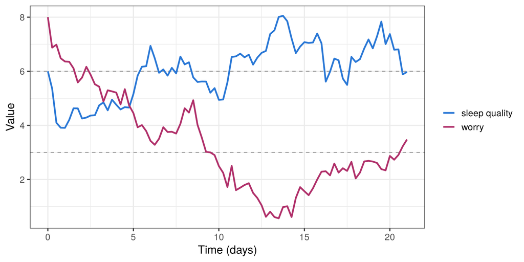

```r
library(ggplot2)

times <- seq(from = 0, to = 21, by = 0.25)
Nsteps <- 20

A1  <- -0.5      # worry returns to rest (slower than sleep)
A2  <- -1.0      # sleep quality returns to rest (faster than worry)
A12 <- -0.3      # effect of sleep quality on worry: better sleep, less worry
A21 <- -0.4      # effect of worry on sleep quality: more worry, worse sleep
B1  <- 3.3       # intercepts: resting levels worry = 3, sleep = 6
B2  <- 7.2
G1  <- 0.8       # kick strength for worry
G2  <- 0.8       # kick strength for sleep quality

simulatePair <- function(startWorry, startSleep, times, Nsteps){
  Nobs <- length(times)
  Worry <- Sleep <- rep(NA, Nobs)
  worryState <- startWorry
  sleepState <- startSleep
  for(i in 1:Nobs){
    if(i > 1){
      dt <- (times[i] - times[i-1]) / Nsteps
      for(stepi in 1:Nsteps){
        dWorry <- A1*worryState + A12*sleepState + B1     # row 1: what drives worry
        dSleep <- A21*worryState + A2*sleepState + B2     # row 2: what drives sleep
        worryState <- worryState + dWorry * dt + G1 * sqrt(dt) * rnorm(1)
        sleepState <- sleepState + dSleep * dt + G2 * sqrt(dt) * rnorm(1)
      }
    }
    Worry[i] <- worryState
    Sleep[i] <- sleepState
  }
  data.frame(time = times, Worry = Worry, Sleep = Sleep)
}

set.seed(25)
# a very worried day
sim <- simulatePair(startWorry = 8, startSleep = 6, times = times, Nsteps = Nsteps)

long <- rbind(data.frame(time = sim$time, value = sim$Worry, construct = "worry"),
              data.frame(time = sim$time, value = sim$Sleep, construct = "sleep quality"))
ggplot(long, aes(x = time, y = value, colour = construct)) +
  geom_hline(yintercept = c(3, 6), linetype = "dashed", colour = "grey60") +
  geom_line(linewidth = 1) +
  scale_colour_manual(values = c(worry = "#b0306a", "sleep quality" = "#2a78d6")) +
  theme_bw(base_size = 14) +
  labs(x = "Time (days)", y = "Value", colour = NULL)
```

Do **not** update worry and then use the new worry to compute sleep’s slope in the same small step. Compute both slopes first, then update both states. (The one exception is the oscillating shock in Oscillation.)

## 6.2 How do I choose B1 and B2 so that both constructs rest where I want?

At rest both slopes are 0, so `B1 <- -(A1*rest1 + A12*rest2)` and `B2 <- -(A21*rest1 + A2*rest2)`. Check: without kicks and starting at rest, both lines must stay flat.

With coupling, $B_1$ alone does not say where construct 1 rests: its resting level also depends on the other construct. Setting the resting levels and computing the intercepts from them means you can change any `A` without the resting levels moving.

```r
library(ggplot2)

times <- seq(from = 0, to = 14, by = 0.25)
Nsteps <- 20
A1 <- -0.5; A2 <- -1.0; A12 <- -0.3; A21 <- -0.4
rest <- c(worry = 3, sleep = 6)   # <-- NEW: where you want them to rest

B1 <- -(A1*rest[1] + A12*rest[2])                     # <-- NEW
B2 <- -(A21*rest[1] + A2*rest[2])                     # <-- NEW
c(B1 = unname(B1), B2 = unname(B2))                   # 3.3 and 7.2
```

```
##  B1  B2
## 3.3 7.2
```

```r
# the check: no kicks, start at rest
worryState <- rest[1]; sleepState <- rest[2]
Worry <- Sleep <- rep(NA, length(times))
Worry[1] <- worryState; Sleep[1] <- sleepState
for (i in 2:length(times)) {
  dt <- (times[i] - times[i-1]) / Nsteps
  for (stepi in 1:Nsteps) {
    dWorry <- A1*worryState + A12*sleepState + B1
    dSleep <- A21*worryState + A2*sleepState + B2
    worryState <- worryState + dWorry * dt
    sleepState <- sleepState + dSleep * dt
  }
  Worry[i] <- worryState; Sleep[i] <- sleepState
}
range(Worry); range(Sleep)        # both stay exactly at their resting level
```

```
## [1] 3 3
```

```
## [1] 6 6
```

With a third construct, every `B` gets one more term; see A third construct.

## 6.3 How do I add a third construct?

Exactly as for two constructs, one more time. For the new construct you add: (1) a parameter for its own pull (`A3`), its intercept (`B3`) and its kicks (`G3`); (2) a state (`fatigueState`) and a vector to store it (`Fatigue`); (3) a slope line (`dFatigue <- ...`) and an update line. Then (4) put a term for the new construct into the slopes of the constructs it affects, e.g. `+ A13*fatigueState` in `dWorry`.

The example adds **fatigue** ($\eta_3$, higher = more tired) to worry and sleep quality. Poor sleep makes Albert more tired ($A_{cross_{32}} < 0$: better sleep, less fatigue), and fatigue makes him worry more ($A_{cross_{13}} > 0$). Every slope now has the same pattern: its own pull, one term for each other construct, and an intercept.

$$\begin{aligned}
\frac{d\eta_1}{dt} &= A_1\,\eta_1 + A_{cross_{12}}\,\eta_2 +
A_{cross_{13}}\,\eta_3 + B_1\\
\frac{d\eta_2}{dt} &= A_{cross_{21}}\,\eta_1 + A_2\,\eta_2 +
A_{cross_{23}}\,\eta_3 + B_2\\
\frac{d\eta_3}{dt} &= A_{cross_{31}}\,\eta_1 +
A_{cross_{32}}\,\eta_2 + A_3\,\eta_3 + B_3
\end{aligned}$$

Writing **all** cross terms, also the ones that are 0, makes it easy to switch on a link later: just change its value. The first number in a name is the construct that changes, the second is the one doing the pushing: `A13` is the effect of fatigue (3) on worry (1).

```r
library(ggplot2)

times <- seq(from = 0, to = 21, by = 0.25)
Nsteps <- 20

# --- own pulls ------------------------------------------------------------------
A1 <- -0.5       # worry returns to rest
A2 <- -1.0       # sleep quality returns to rest
A3 <- -0.8       # <-- NEW: fatigue returns to rest

# --- couplings (first number: the construct that changes; second: the pusher) --
A12 <- -0.3      # sleep quality -> worry: better sleep, less worry
A13 <-  0.2      # <-- NEW: fatigue -> worry: more fatigue, more worry
A21 <- -0.4      # worry -> sleep quality: more worry, worse sleep
A23 <-  0        # <-- NEW: fatigue -> sleep quality: no effect
A31 <-  0        # <-- NEW: worry -> fatigue: no effect
A32 <- -0.5      # <-- NEW: sleep quality -> fatigue: better sleep, less fatigue

# --- resting levels and the intercepts that put them there ----------------------
rest1 <- 3; rest2 <- 6; rest3 <- 4          # worry, sleep quality, fatigue (rest3 is NEW)
B1 <- -(A1*rest1  + A12*rest2 + A13*rest3)  # <-- CHANGE: one more term
B2 <- -(A21*rest1 + A2*rest2  + A23*rest3)  # <-- CHANGE: one more term
B3 <- -(A31*rest1 + A32*rest2 + A3*rest3)   # <-- NEW

# --- kicks -----------------------------------------------------------------------
G1 <- 0.25; G2 <- 0.25
G3 <- 0.25       # <-- NEW

simulateThree <- function(startWorry, startSleep, startFatigue, times, Nsteps){
  Nobs <- length(times)
  Worry <- Sleep <- Fatigue <- rep(NA, Nobs)                     # <-- CHANGE: one more vector
  worryState <- startWorry
  sleepState <- startSleep
  fatigueState <- startFatigue                                   # <-- NEW
  for(i in 1:Nobs){
    if(i > 1){
      dt <- (times[i] - times[i-1]) / Nsteps
      for(stepi in 1:Nsteps){
        # first all slopes, from the current states ...
        dWorry   <- A1*worryState  + A12*sleepState + A13*fatigueState + B1   # <-- CHANGE
        dSleep   <- A21*worryState + A2*sleepState  + A23*fatigueState + B2   # <-- CHANGE
        dFatigue <- A31*worryState + A32*sleepState + A3*fatigueState  + B3   # <-- NEW
        # ... then all updates
        worryState   <- worryState   + dWorry * dt   + G1 * sqrt(dt) * rnorm(1)
        sleepState   <- sleepState   + dSleep * dt   + G2 * sqrt(dt) * rnorm(1)
        fatigueState <- fatigueState + dFatigue * dt + G3 * sqrt(dt) * rnorm(1)   # <-- NEW
      }
    }
    Worry[i] <- worryState
    Sleep[i] <- sleepState
    Fatigue[i] <- fatigueState                                   # <-- NEW
  }
  data.frame(time = times, Worry = Worry, Sleep = Sleep, Fatigue = Fatigue)
}

set.seed(26)
sim <- simulateThree(startWorry = rest1, startSleep = 1, startFatigue = rest3,   # a very bad night
                     times = times, Nsteps = Nsteps)
head(round(sim, 2))
```

```
##   time Worry Sleep Fatigue
## 1 0.00  3.00  1.00    4.00
## 2 0.25  3.23  2.23    4.44
## 3 0.50  3.53  2.90    4.68
## 4 0.75  3.80  3.53    4.69
## 5 1.00  3.88  4.12    4.91
## 6 1.25  4.20  4.58    4.75
```

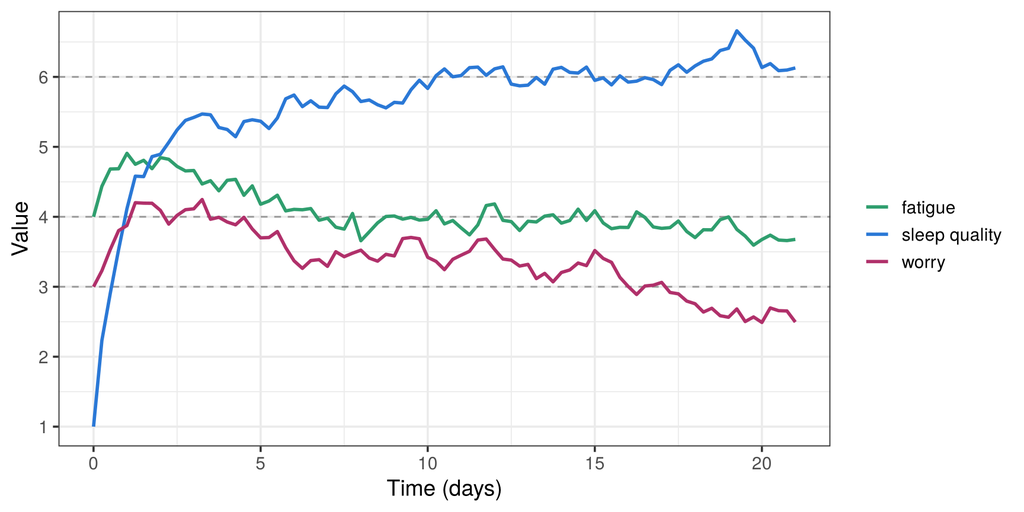

```r
long <- rbind(data.frame(time = sim$time, value = sim$Worry,   construct = "worry"),
              data.frame(time = sim$time, value = sim$Sleep,   construct = "sleep quality"),
              data.frame(time = sim$time, value = sim$Fatigue, construct = "fatigue"))
ggplot(long, aes(x = time, y = value, colour = construct)) +
  geom_hline(yintercept = c(rest1, rest2, rest3), linetype = "dashed", colour = "grey60") +
  geom_line(linewidth = 1) +
  scale_colour_manual(values = c(worry = "#b0306a", "sleep quality" = "#2a78d6",
                                 fatigue = "#2f9e6e")) +
  theme_bw(base_size = 14) +
  labs(x = "Time (days)", y = "Value", colour = NULL)
```

After a bad night, fatigue rises, and worry rises too: directly because of the poor sleep, and a little later because of the fatigue. For a fourth construct, repeat the same four steps.

Check the new intercepts the same way as for two constructs: run once without kicks (`G1 <- G2 <- G3 <- 0`) and with every construct starting at its resting level. All three lines must stay flat. If one moves, a term is missing in a slope or in a `B`.

## 6.4 How do I check whether my coupled system comes back to rest (stability)?

Simulate **without kicks**, start one construct away from its resting level, and let it run long enough. If all constructs return to rest, the system is stable. If they drift further and further away, it runs away. For two constructs there is also a quick rule: the system is stable if `A1 + A2 < 0` and `A1*A2 - A12*A21 > 0`.

Negative own pulls (`A1`, `A2`) are not enough: two constructs that push each other strongly can run away together, because each one’s push on the other is stronger than their own pulls back. The simulation check works for any number of constructs.

```r
library(ggplot2)

times <- seq(from = 0, to = 10, by = 0.1)
Nsteps <- 10
A1 <- -0.6; A2 <- -0.4
rest1 <- 5; rest2 <- 5

simulateNoKicks <- function(A12, A21, startAlbert, startRabbit){
  B1 <- -(A1*rest1 + A12*rest2)
  B2 <- -(A21*rest1 + A2*rest2)
  Albert <- Rabbit <- rep(NA, length(times))
  albertState <- startAlbert; rabbitState <- startRabbit
  Albert[1] <- albertState; Rabbit[1] <- rabbitState
  for (i in 2:length(times)) {
    dt <- (times[i] - times[i-1]) / Nsteps
    for (stepi in 1:Nsteps) {
      dAlbert <- A1*albertState + A12*rabbitState + B1
      dRabbit <- A21*albertState + A2*rabbitState + B2
      albertState <- albertState + dAlbert * dt            # no kicks
      rabbitState <- rabbitState + dRabbit * dt
    }
    Albert[i] <- albertState; Rabbit[i] <- rabbitState
  }
  data.frame(time = times, Albert = Albert, Rabbit = Rabbit)
}

# the quick rule for two constructs
c(weak = A1*A2 - 0.3*0.3, strong = A1*A2 - 1*1)   # positive: stable; negative: runs away
```

```
##   weak strong
##   0.15  -0.76
```

```r
weak   <- simulateNoKicks(A12 = 0.3, A21 = 0.3, startAlbert = 5, startRabbit = 1)
strong <- simulateNoKicks(A12 = 1,   A21 = 1,   startAlbert = 5, startRabbit = 1)

# the simulation check: how far from rest at the end?
c(weak = abs(tail(weak$Albert, 1) - rest1), strong = abs(tail(strong$Albert, 1) - rest1))
```

```
##        weak      strong
##   0.3009885 306.5374018
```

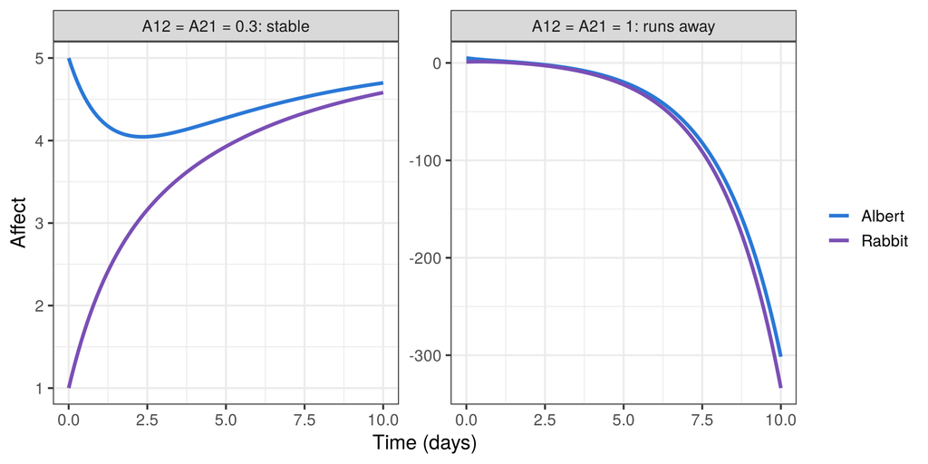

```r
dat <- rbind(data.frame(weak, coupling = "A12 = A21 = 0.3: stable"),
             data.frame(strong, coupling = "A12 = A21 = 1: runs away"))
long <- rbind(data.frame(dat[, c("time", "coupling")], value = dat$Albert, who = "Albert"),
              data.frame(dat[, c("time", "coupling")], value = dat$Rabbit, who = "Rabbit"))

ggplot(long, aes(x = time, y = value, colour = who)) +
  geom_line(linewidth = 1.2) +
  facet_wrap(~ coupling, scales = "free_y") +
  scale_colour_manual(values = c(Albert = "#2a78d6", Rabbit = "#7a4fb5")) +
  theme_bw(base_size = 14) +
  labs(x = "Time (days)", y = "Affect", colour = NULL)
```